# RNA-seq 工作流程: 基因水平的探索性分析和差异表达分析

Michael I. Love, Simon Anders, Vladislav Kim and Wolfgang Huber

Department of Biostatistics, UNC-Chapel Hill, Chapel Hill, NC, US  
Department of Genetics, UNC-Chapel Hill, Chapel Hill, NC, US  
Zentrum für Molekulare Biologie der Universität Heidelberg, Heidelberg, Germany  
European Molecular Biology Laboratory (EMBL), Heidelberg, Germany

11 April, 2018

#### Abstract

这里我们使用Bioconductor包执行一个端到端的基因水平RNA-seq差异表达分析工作流程。 我们会从FASTQ文件开始， 展示如何与参考基因组比对，如何准备每个样本中每个基因的RNA-seq片段的计数矩阵。 我们会进行探索性数据分析（EDA）以完成质量评估，并且为了探索样本之间的关系，执行差异基因表达分析，最后对结果进行可视化。

# Contents

**R version**: R version 3.5.2 (2018-12-20)

**Bioconductor version**: 3.8

**Package**: 1.4.1

# 1 介绍

Bioconductor有许多支持高通量序列数据分析的包, 包括RNA sequencing (RNA-seq)。 我们在这个工作流中使用的包包括由Bioconductor核心团队维护的核心包，其是用来导入 和处理原始的序列数据并加载基因注释的。我们也会用其他的包进行统计分析和数据可视化。 通过每6个月一次的发布计划，bioconductor项目可以确保所有发布的包在整体上运行流畅。 （这也是“conductor”这一词的隐喻）。本工作流中使用的包用 *library* 函数加载，并可以通过以下链接安装 [Bioconductor 包安装说明](http://bioconductor.org/install/#install-bioconductor-packages)。

此工作流程的已发布（但基本相似）版本，包括审阅报告和评论见 [F1000Research](http://f1000research.com/articles/4-1070)。

如果您对此工作流程或Bioconductor软件有任何疑问，请将这些发布到 [Bioconductor support site](https://support.bioconductor.org/). 如果你的问题涉及特定的包，你可以在发布中加上包的名字作为标签, 如果是关于工作流的一般性问题, 在发布中加上标签`rnaseqgene`。参考 [发布指南](http://www.bioconductor.org/help/support/posting-guide/) 以使你在网站中发布的问题合乎规范。

## 1.1 实验数据

本工作流程使用数据存储在 *airway* 包中，这是一个用地塞米松 （一种合成的有抗炎作用的糖皮质激素）处理呼吸道平滑肌细胞的RNA-seq实验 (Himes et al. 2014)。糖皮质激素被用于，诸如，减少哮喘病人的呼吸道炎症。实验中， 四个原代的人呼吸道平滑肌细胞系用1μmol地塞米松处理18小时，每个细胞系都有一个处理的样本 和未处理的对照样本。关于实验的更多内容参见 [PubMed entry 24926665](http://www.ncbi.nlm.nih.gov/pubmed/24926665)， 实验的原始数据参见 [GEO entry GSE52778](http://www.ncbi.nlm.nih.gov/geo/query/acc.cgi?acc=GSE52778)。

# 2 准备计数矩阵

对于输入数据，基于计数的统计方法，如 *DESeq2* (Love, Huber, and Anders 2014), *edgeR* (M. D. Robinson, McCarthy, and Smyth 2009), *limma* with the voom method (Law et al. 2014), *DSS* (H. Wu, Wang, and Wu 2013), *EBSeq* (Leng et al. 2013) and *baySeq* (Hardcastle and Kelly 2010), 期望的输入数据是从RNA-seq等高通量测序实验中获得的，以整数矩阵的格式呈现的数据。 矩阵中 *i* 行和 *j* 列的值表示有多少reads（或者是fragments， 对于双端RNA-seq来说）已经分配给了样本 *j* 中的基因 *i*。类似的，对于其他类型的实验， 矩阵的行可以对应于诸如：结合区域（ChIP-Seq），细菌种类（宏基因组数据集）或蛋白序列（定量质谱）。

矩阵中的值应该是测序的reads/fragments计数，这一点对于维持 *DESeq2* 统计模型的正常 运行十分重要，因为只有计数值才能正确的评估测量的精确度。最重要的是不要使用由测序深度 或文库大小进行了预标准化的计数值，因为统计模型使用未标准化的计数时效果最好，并且其在设计时 内部已经考虑了文库大小的差异。

## 2.1 推荐: 转录本丰度和 *tximport* pipeline

在演示如何比对并计数RNA-seq片段之前，我们提及一种更新更快的用于转录本丰度定量的可选的 pipeline，诸如： [Salmon](https://combine-lab.github.io/salmon/) (Patro et al. 2017)， [Sailfish](http://www.cs.cmu.edu/~ckingsf/software/sailfish/) (Patro, Mount, and Kingsford 2014)， [kallisto](https://pachterlab.github.io/kallisto/) (Bray et al. 2016)，或者 [RSEM](http://deweylab.github.io/RSEM/) (B. Li and Dewey 2011)， 在没有比对reads的情况下估算转录丰度，接着用 *tximport* 包来组装 估算的计数并为Bioconductor差异基因表达包提供使用的矩阵。

这是一个关于如何使用 *Salmon* 软件来定量转录本丰度的教程 [（点击此处）](https://combine-lab.github.io/salmon/getting_started/). 我们建议使用 `--gcBias` [flag](http://salmon.readthedocs.io/en/latest/salmon.html#gcbias) 为RNA-seq数据中常见的系统偏差估算一个校正因子 (Love, Hogenesch, and Irizarry 2016; Patro et al. 2017)， 除非你确信你的数据没有这样的偏差。 按照Salmon教程，你可以使用 [tximport vignette](https://bioconductor.org/packages/release/bioc/vignettes/tximport/inst/doc/tximport.html)， 中的步骤，其将展示如何建立一个 *DESeqDataSet*。这是我们目前推荐给用户的pipeline， 但是下面我们仍然会包含关于基因组reads比对和从BAM文件中建立计数矩阵的步骤。

协同使用转录本丰度量化软件和 *tximport* 来产生基因水平的计数矩阵和标准化补偿的优势是： 这种途径纠正了不同样本间基因长度的潜在改变 (如差异异构体造成的改变） (Trapnell et al. 2013)；与基于比对的方法相比，这些方法中的其中一些方法 速度更快，所需的内存和磁盘使用量更少，并且可以避免丢弃那些可以与同源序列的多个基因比对上 的片段(Robert and Watson 2015)。注意，转录本丰度量化软件不产生存储read aligments的 大文件，而是产生存储着估算丰度，计数值以及每个转录本有效长度的小文件。更多细节请参考相关 的手册(Soneson, Love, and Robinson 2015)，以及概括了软件细节的 *tximport* 包。使用了转录本量化软件和 *tximport* 后回到此工作流的 入口点在 section on exploratory data analysis 下面。

## 2.2 将reads比对到参考基因组上

RNA-seq实验的计算机分析从FASTQ文件开始，该文件含有每个read的核苷酸序列和每个位点的质量分数。 这些reads首先与参考基因组或转录组进行比对，或者像上面描述的那样，在未比对的情况下估算 转录本的丰度和计数值。不管哪种情况，知道这个测序实验是双端还是单端的很重要，因为比对软件会 要求用户为双端实验指定两个FASTQ文件。此比对步骤的输出通常存储在一个 [SAM/BAM](http://samtools.github.io/hts-specs)格式的文件中。

许多的软件都能进行和参考基因组的read比对，我们建议你查阅一些国际上的相关文献，这些文献讨论了 各种软件在精度，拼接点处的比对灵敏度，速度，内存要求，实用性以及许多其他特点上的优缺点， 我们在这里使用 [STAR read aligner](https://code.google.com/p/rna-star/) (Dobin et al. 2013) 来将我们当前实验的reads和 Ensembl release 75 (Flicek et al. 2014)人类参考及基因组进行比对。 在下面的示例代码中，假设当前目录中有一个名为`files`的文件，文件的每一行都包含每个实验的标识符， 所有的FASTQ文件在二级目录`fastq`中。如果你已经从Sequence Read Archive下载了FASTQ文件， 那么标识符就是SRA run IDs，比如`SRR1039520`。双端实验的每个ID有两个文件，`fastq/SRR1039520_1.fastq1`和`fastq/SRR1039520_2.fastq`，分别表示双端片段的第一个 和第二个read。如果你执行的是单端实验，那么每个ID只有一个文件。我们也建立了一个二级目录`aligned`， STAR在这里输出它的比对文件。

```
for f in `cat files`; do STAR --genomeDir ../STAR/ENSEMBL.homo_sapiens.release-75 \
--readFilesIn fastq/$f\_1.fastq fastq/$f\_2.fastq \
--runThreadN 12 --outFileNamePrefix aligned/$f.; done
```

[SAMtools](http://www.htslib.org/doc/samtools.html) (H. Li et al. 2009) 用于产生BAM文件。`-@` 标记用于分配额外的线程。

```
for f in `cat files`; do samtools view -bS aligned/$f.Aligned.out.sam \
-o aligned/$f.bam; done
```

BAM文件可以用于生成计数矩阵，这会在下面的章节中进行描述。

## 2.3 定位比对文件

除了后面要用的计数矩阵，*airway* 包还包含8个文件，这是实验中全部数目 的reads的一个小子集，选择的是与1号染色体的一个小区域比对的reads。出于演示的目的，我们 选择了reads的一个子集，因为完整的比对文件太大了（大约几个GB），而且计算每个样本的 fragments需要10-30分钟。我们会使用这些文件来演示如何从BAM文件中建立一个计数矩阵。之后， 我们会加载完整的对应于全部样本和全部数据的计数矩阵，该矩阵在 *airway* 包中同样有提供，后续的分析会使用完整的矩阵。

加载有示例数据的数据包：

```r
library("airway")
```

R函数 *system.file* 用于查找来自包中的文件在你的计算机中上的安装位置。这里我们要求提供 `extdata`目录的完整路径，这个目录是R包用来存储外部数据的，是 *airway* 包的一部分。

```r
indir <- system.file("extdata", package="airway", mustWork=TRUE)
```

在这个目录中，我们找到了8个BAM文件(以及其他的一些文件):

```r
list.files(indir)
```

```
##  [1] "GSE52778_series_matrix.txt"        "Homo_sapiens.GRCh37.75_subset.gtf"
##  [3] "sample_table.csv"                  "SraRunInfo_SRP033351.csv"
##  [5] "SRR1039508_subset.bam"             "SRR1039509_subset.bam"
##  [7] "SRR1039512_subset.bam"             "SRR1039513_subset.bam"
##  [9] "SRR1039516_subset.bam"             "SRR1039517_subset.bam"
## [11] "SRR1039520_subset.bam"             "SRR1039521_subset.bam"
```

通常，我们会有一个将样本和相应的FASTQ、BAM文件关联起来的详细信息的表格，在你自己的实验中， 你可以用文本编辑器或电子表格软件如Excel建立这样的逗号分隔符文件（CSV）。

我们用 *read.csv* 加载这个CSV文件：

```r
csvfile <- file.path(indir, "sample_table.csv")
sampleTable <- read.csv(csvfile, row.names = 1)
sampleTable
```

```
##            SampleName    cell   dex albut        Run avgLength Experiment
## SRR1039508 GSM1275862  N61311 untrt untrt SRR1039508       126  SRX384345
## SRR1039509 GSM1275863  N61311   trt untrt SRR1039509       126  SRX384346
## SRR1039512 GSM1275866 N052611 untrt untrt SRR1039512       126  SRX384349
## SRR1039513 GSM1275867 N052611   trt untrt SRR1039513        87  SRX384350
## SRR1039516 GSM1275870 N080611 untrt untrt SRR1039516       120  SRX384353
## SRR1039517 GSM1275871 N080611   trt untrt SRR1039517       126  SRX384354
## SRR1039520 GSM1275874 N061011 untrt untrt SRR1039520       101  SRX384357
## SRR1039521 GSM1275875 N061011   trt untrt SRR1039521        98  SRX384358
##               Sample    BioSample
## SRR1039508 SRS508568 SAMN02422669
## SRR1039509 SRS508567 SAMN02422675
## SRR1039512 SRS508571 SAMN02422678
## SRR1039513 SRS508572 SAMN02422670
## SRR1039516 SRS508575 SAMN02422682
## SRR1039517 SRS508576 SAMN02422673
## SRR1039520 SRS508579 SAMN02422683
## SRR1039521 SRS508580 SAMN02422677
```

完成reads比对后，有许多的工具可以用于计算每个样本中能与参考基因组比对上的reads/fragments的 数目。这些工具需要输入以下文件：SAM/BAM文件和一个指定基因组特征的文件，比如一个指定基因模型的GFF3 或GTF文件。

## 2.4 *DESeq2* 导入函数

下列工具可以被用于生成计数矩阵： *summarizeOverlaps* (Lawrence et al. 2013), *featureCounts* (Liao, Smyth, and Shi 2014), *tximport* (Soneson, Love, and Robinson 2015), *htseq-count* (Anders, Pyl, and Huber 2015).

| function | package | framework | output | *DESeq2* input function |
| --- | --- | --- | --- | --- |
| *summarizeOverlaps* | *GenomicAlignments* | R/Bioconductor | *SummarizedExperiment* | *DESeqDataSet* |
| *featureCounts* | *Rsubread* | R/Bioconductor | matrix | *DESeqDataSetFromMatrix* |
| *tximport* | *tximport* | R/Bioconductor | list of matrices | *DESeqDataSetFromTximport* |
| *htseq-count* | HTSeq | Python | files | *DESeqDataSetFromHTSeq* |

这里我们用 *summarizeOverlaps* 来处理。 使用样本表格中的 `Run` 列，我们建立想在其上执行计数操作的文件的完整路径：

```r
filenames <- file.path(indir, paste0(sampleTable$Run, "_subset.bam"))
file.exists(filenames)
```

```
## [1] TRUE TRUE TRUE TRUE TRUE TRUE TRUE TRUE
```

*Rsamtools* 包给BAM文件提供了一个R接口，利用其中的 *BamFileList* 函数指定应用于 这里的文件。这里我们也指出了关于如何处理BAM文件的细节，比如一次只能处理200万的reads，键入 `?BamFileList` 可以获得更多信息。

```r
library("Rsamtools")
bamfiles <- BamFileList(filenames, yieldSize=2000000)
```

**Note:** 确保你在注释中使用的基因组的染色体名称与用于read比对参考的染色体名称是一致的。 否则，脚本会由于名称错配而无法计算出符合特征的任何reads。例如，一个常见的错误是，比对文件中的 染色体名称是 `1`，而基因注释的染色体名称是 `chr1`，或者正好相反。解决方法见 *GenomeInfoDb* 包中的 *seqlevelsStyle* 函数。 我们可以像这样检查比对文件中的染色体名称（这里称为 “seqnames”）：

```r
seqinfo(bamfiles[1])
```

```
## Seqinfo object with 84 sequences from an unspecified genome:
##   seqnames   seqlengths isCircular genome
##   1           249250621       <NA>   <NA>
##   10          135534747       <NA>   <NA>
##   11          135006516       <NA>   <NA>
##   12          133851895       <NA>   <NA>
##   13          115169878       <NA>   <NA>
##   ...               ...        ...    ...
##   GL000210.1      27682       <NA>   <NA>
##   GL000231.1      27386       <NA>   <NA>
##   GL000229.1      19913       <NA>   <NA>
##   GL000226.1      15008       <NA>   <NA>
##   GL000207.1       4262       <NA>   <NA>
```

## 2.5 定义基因模型

接下来，需要读入一个计数reads/fragments的基因模型。我们使用 *GenomicFeatures* 包中的 *makeTxDbFromGFF* 函数从Ensembl的一个 [GTF文件](http://www.ensembl.org/info/website/upload/gff.html) (Flicek et al. 2014) 中读入基因模型。GTF文件可以从 [Ensembl的FTP站点](http://www.ensembl.org/info/data/ftp/) 或者其他的基因模型仓库中下载。 本节的主要目的是为构建一个 *TxDb* 对象，即能够用来生成一系列区段，如外显子、转录本以及基因的数据库。 我们想要制作一个按基因分组的外显子列表，用于计算reads/fragments。

也有其他的构建 *TxDb* 的方法。 对于从 UCSC Genome Browser (Kent et al. 2002)追踪到的 *known genes* ，您可以使用预先建立的 转录本数据库：*TxDb.Hsapiens.UCSC.hg19.knownGene*。 如果注释文件可以从 *AnnotationHub* 获取（像Ensembl基因一样）， 那么可以用 *makeTxDbFromGRanges* 函数导入一个预选扫描好的GFT文件。

这里我们演示从GFT文件处加载：

```r
library("GenomicFeatures")
```

我们使用一个0长度的字符矢量来指明没有一个序列（染色体）是环状的。

```r
gtffile <- file.path(indir,"Homo_sapiens.GRCh37.75_subset.gtf")
txdb <- makeTxDbFromGFF(gtffile, format = "gtf", circ_seqs = character())
txdb
```

```
## TxDb object:
## # Db type: TxDb
## # Supporting package: GenomicFeatures
## # Data source: /Library/Frameworks/R.framework/Versions/3.5/Resources/library/airway/extdata/Homo_sapiens.GRCh37.75_subset.gtf
## # Organism: NA
## # Taxonomy ID: NA
## # miRBase build ID: NA
## # Genome: NA
## # transcript_nrow: 65
## # exon_nrow: 279
## # cds_nrow: 158
## # Db created by: GenomicFeatures package from Bioconductor
## # Creation time: 2019-03-06 16:03:31 +0800 (Wed, 06 Mar 2019)
## # GenomicFeatures version at creation time: 1.34.3
## # RSQLite version at creation time: 2.1.1
## # DBSCHEMAVERSION: 1.2
```

下面这行生成了一个按基因(Lawrence et al. 2013)分组的所有外显子的 *GRangesList* 。 列表中的每一个元素是一个基因的外显子的 *GRanges* 对象。

```r
ebg <- exonsBy(txdb, by="gene")
ebg
```

```
## GRangesList object of length 20:
## $ENSG00000009724
## GRanges object with 18 ranges and 2 metadata columns:
##        seqnames            ranges strand |   exon_id       exon_name
##           <Rle>         <IRanges>  <Rle> | <integer>     <character>
##    [1]        1 11086580-11087705      - |        98 ENSE00000818830
##    [2]        1 11090233-11090307      - |        99 ENSE00000472123
##    [3]        1 11090805-11090939      - |       100 ENSE00000743084
##    [4]        1 11094885-11094963      - |       101 ENSE00000743085
##    [5]        1 11097750-11097868      - |       102 ENSE00003482788
##    ...      ...               ...    ... .       ...             ...
##   [14]        1 11106948-11107176      - |       111 ENSE00003467404
##   [15]        1 11106948-11107176      - |       112 ENSE00003489217
##   [16]        1 11107260-11107280      - |       113 ENSE00001833377
##   [17]        1 11107260-11107284      - |       114 ENSE00001472289
##   [18]        1 11107260-11107290      - |       115 ENSE00001881401
##
## ...
## <19 more elements>
## -------
## seqinfo: 1 sequence from an unspecified genome; no seqlengths
```

## 2.6 Read计数步骤

经过这些准备工作，实际的计算是很容易的。 *GenomicAlignments*包中的 *summarizeOverlaps* 函数执行这个操作。这会产生一个 *SummarizedExperiment* 对象， 其中包含此实验的各种信息，并且下面会描述出更多的细节。

**Note:** 如果是用多核执行的计算，你可以在 the counting call below 之前使用 *BiocParallel* 包中的 *register* 和 *MulticoreParam* 或 *SnowParam* 函数。预计对于有3000万比对reads的人RNA-seq文件， `summarizeOverlaps` 的调用将会耗费至少 30分钟每文件。把文件发送给不同的核心，计算过程会得到加速。

```r
library("GenomicAlignments")
library("BiocParallel")
```

这里我们指定使用单核，而不是多核。我们也可以跳过这一行，那么计数过程将会连续执行。

```r
register(SerialParam())
```

The following call creates the *SummarizedExperiment* object with counts:

```r
se <- summarizeOverlaps(features=ebg, reads=bamfiles,
                        mode="Union",
                        singleEnd=FALSE,
                        ignore.strand=TRUE,
                        fragments=TRUE )
```

我们在 `features` 和 `reads` 之外指定了许多的arguments。`mode` argument描述了何种 read overlaps将会被计数。 这些modes展示在简介*GenomicAlignments* 包 的 *Counting reads with summarizeOverlaps* 的图1中。 注意fragments在每个基因中只会被计数一次，即使它们在一个基因的多个外显子中重复。 将 `singleEnd` 设置为 `FALSE` 表明实验产生双端的reads，并且我们想在一个基因的计算过程中 将一对reads只计算一次。 The `fragments` argument can be used when `singleEnd=FALSE` to specify if unpaired reads should be counted (yes if `fragments=TRUE`).

为了生成正确的计数值，弄清楚RNA-seq实验是否是链特异性的很重要。 这个实验不是链特异性的，所以我们 设置 `ignore.strand` 为 `TRUE`。 然而，有些链特异性方案只能与基因的互补链进行reads比对。 用户必须检查其实验是否是链特异性的，如果是，reads应该同基因的正链还是负链比对。 对于各种计数/量化工具，我们指定以不同的方式对正向或反向链进行计数， 目前这个任务用 *htseq-count*， *featureCounts*, 或者前面提到的转录本量化软件都能很容易的完成。 检查计数矩阵的（见下）的总列数是非常好的，以此来确保其与预期的基因比对的reads或fragments数目相 匹配。此外，可以用基因组可视化工具来直观地检查read alignments。

## 2.7 SummarizedExperiment查看

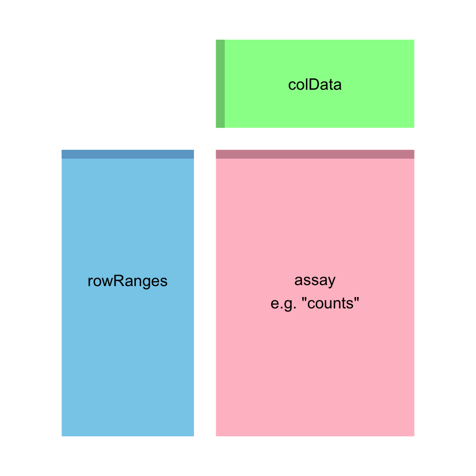

**The component parts of a *SummarizedExperiment* object.** `assay` （粉色块） 中包含了计数矩阵， `rowRanges` （蓝色快）中包含基因组范围信息， `colData` （绿色快）包含 样本信息。每个色块中高亮的行表示第一行（注意 `colData` 的第一行与`assay`的第一列是并齐的。）

*SummarizedExperiment* container上图有图解，并在最新的Bioconductor文章中有讨论 (Huber et al. 2015)。在我们的案例中，我们建立了一个名为“counts”的单矩阵，其包含 每个样本和每个基因的fragment计数值，其存储于 `assay`中。也可以存储多矩阵，用 `assays` 访问. 我们的对象中的 `rowRanges` 是 *GRangesList* ，用于计数。（计数矩阵中的每一行有一个外显子的 *GRanges* ）。使用同名的R函数访问 *summarzedexperiment* 的组件部分：`assay` (or `assays`), `rowRanges` and `colData`。

上面的示例代码实际上只计算了原始实验的fragments的一小部分。尽管如此,我们仍然可以 investigate the resulting *SummarizedExperiment* by looking at the counts in the `assay` slot, 关于样本的表型数据在 `colData` 插槽中（本例中一个空的 *DataFrame*），关于基因的数据在 `rowRanges` 插槽中。

```r
se
```

```
## class: RangedSummarizedExperiment
## dim: 20 8
## metadata(0):
## assays(1): counts
## rownames(20): ENSG00000009724 ENSG00000116649 ... ENSG00000271794
##   ENSG00000271895
## rowData names(0):
## colnames(8): SRR1039508_subset.bam SRR1039509_subset.bam ...
##   SRR1039520_subset.bam SRR1039521_subset.bam
## colData names(0):
```

```r
dim(se)
```

```
## [1] 20  8
```

```r
assayNames(se)
```

```
## [1] "counts"
```

```r
head(assay(se), 3)
```

```
##                 SRR1039508_subset.bam SRR1039509_subset.bam
## ENSG00000009724                    38                    28
## ENSG00000116649                  1004                  1255
## ENSG00000120942                   218                   256
##                 SRR1039512_subset.bam SRR1039513_subset.bam
## ENSG00000009724                    66                    24
## ENSG00000116649                  1122                  1313
## ENSG00000120942                   233                   252
##                 SRR1039516_subset.bam SRR1039517_subset.bam
## ENSG00000009724                    42                    41
## ENSG00000116649                  1100                  1879
## ENSG00000120942                   269                   465
##                 SRR1039520_subset.bam SRR1039521_subset.bam
## ENSG00000009724                    47                    36
## ENSG00000116649                   745                  1536
## ENSG00000120942                   207                   400
```

```r
colSums(assay(se))
```

```
## SRR1039508_subset.bam SRR1039509_subset.bam SRR1039512_subset.bam
##                  6478                  6501                  7699
## SRR1039513_subset.bam SRR1039516_subset.bam SRR1039517_subset.bam
##                  6801                  8009                 10849
## SRR1039520_subset.bam SRR1039521_subset.bam
##                  5254                  9168
```

`rowRanges`在打印时,只展示第一个*GRanges*，并告诉我们还有19个元素：

```r
rowRanges(se)
```

```
## GRangesList object of length 20:
## $ENSG00000009724
## GRanges object with 18 ranges and 2 metadata columns:
##        seqnames            ranges strand |   exon_id       exon_name
##           <Rle>         <IRanges>  <Rle> | <integer>     <character>
##    [1]        1 11086580-11087705      - |        98 ENSE00000818830
##    [2]        1 11090233-11090307      - |        99 ENSE00000472123
##    [3]        1 11090805-11090939      - |       100 ENSE00000743084
##    [4]        1 11094885-11094963      - |       101 ENSE00000743085
##    [5]        1 11097750-11097868      - |       102 ENSE00003482788
##    ...      ...               ...    ... .       ...             ...
##   [14]        1 11106948-11107176      - |       111 ENSE00003467404
##   [15]        1 11106948-11107176      - |       112 ENSE00003489217
##   [16]        1 11107260-11107280      - |       113 ENSE00001833377
##   [17]        1 11107260-11107284      - |       114 ENSE00001472289
##   [18]        1 11107260-11107290      - |       115 ENSE00001881401
##
## ...
## <19 more elements>
## -------
## seqinfo: 1 sequence from an unspecified genome; no seqlengths
```

`rowRanges`也含有metadata，其与在 `metadata` 插槽中的基因模型的构建有关。 这里我们使用`str`这个R函数来简洁的展示mmetadata。

```r
str(metadata(rowRanges(se)))
```

```
## List of 1
##  $ genomeInfo:List of 15
##   ..$ Db type                                 : chr "TxDb"
##   ..$ Supporting package                      : chr "GenomicFeatures"
##   ..$ Data source                             : chr "/Library/Frameworks/R.framework/Versions/3.5/Resources/library/airway/extdata/Homo_sapiens.GRCh37.75_subset.gtf"
##   ..$ Organism                                : chr NA
##   ..$ Taxonomy ID                             : chr NA
##   ..$ miRBase build ID                        : chr NA
##   ..$ Genome                                  : chr NA
##   ..$ transcript_nrow                         : chr "65"
##   ..$ exon_nrow                               : chr "279"
##   ..$ cds_nrow                                : chr "158"
##   ..$ Db created by                           : chr "GenomicFeatures package from Bioconductor"
##   ..$ Creation time                           : chr "2019-03-06 16:03:31 +0800 (Wed, 06 Mar 2019)"
##   ..$ GenomicFeatures version at creation time: chr "1.34.3"
##   ..$ RSQLite version at creation time        : chr "2.1.1"
##   ..$ DBSCHEMAVERSION                         : chr "1.2"
```

The `colData`:

```r
colData(se)
```

```
## DataFrame with 8 rows and 0 columns
```

`colData`插槽目前还是空的，它应该包含全部的metadata。因为我们使用`sampleTable` 这一列来生成`bamfiles`矢量，所以我们知道`se`列的顺序和`sampleTable`行的顺序是 一样的。我们可以把`sampleTable`分配为总结性实验的`colData`，这要通过把它转换成 一个*DataFrame*并使用分配函数来实现。

```r
colData(se) <- DataFrame(sampleTable)
colData(se)
```

```
## DataFrame with 8 rows and 9 columns
##            SampleName     cell      dex    albut        Run avgLength
##              <factor> <factor> <factor> <factor>   <factor> <integer>
## SRR1039508 GSM1275862   N61311    untrt    untrt SRR1039508       126
## SRR1039509 GSM1275863   N61311      trt    untrt SRR1039509       126
## SRR1039512 GSM1275866  N052611    untrt    untrt SRR1039512       126
## SRR1039513 GSM1275867  N052611      trt    untrt SRR1039513        87
## SRR1039516 GSM1275870  N080611    untrt    untrt SRR1039516       120
## SRR1039517 GSM1275871  N080611      trt    untrt SRR1039517       126
## SRR1039520 GSM1275874  N061011    untrt    untrt SRR1039520       101
## SRR1039521 GSM1275875  N061011      trt    untrt SRR1039521        98
##            Experiment    Sample    BioSample
##              <factor>  <factor>     <factor>
## SRR1039508  SRX384345 SRS508568 SAMN02422669
## SRR1039509  SRX384346 SRS508567 SAMN02422675
## SRR1039512  SRX384349 SRS508571 SAMN02422678
## SRR1039513  SRX384350 SRS508572 SAMN02422670
## SRR1039516  SRX384353 SRS508575 SAMN02422682
## SRR1039517  SRX384354 SRS508576 SAMN02422673
## SRR1039520  SRX384357 SRS508579 SAMN02422683
## SRR1039521  SRX384358 SRS508580 SAMN02422677
```

## 2.8 分支点

现在，我们已经根据特定的基因模型算出了重叠在基因上的fragments，这是一个分支点，此处我们 可以使用众多的Bioconductor包对算得的数据进行探索和差异表达分析。包括 *edgeR* (M. D. Robinson, McCarthy, and Smyth 2009), *limma* with the voom method (Law et al. 2014), *DSS* (H. Wu, Wang, and Wu 2013), *EBSeq* (Leng et al. 2013) and *baySeq* (Hardcastle and Kelly 2010). Schurch et al. (2016) [compared performance](https://www.ncbi.nlm.nih.gov/pmc/articles/pmid/27022035/) 使用大量生物学重复的RNA-seq的不同统计学方法，可以帮助用户决定使用哪些工具，以及获得一定 灵敏度需要多少生物学重复。 我们会继续使用*DESeq2* (Love, Huber, and Anders 2014)。我们都需要 *SummarizedExperiment*对象来开始我们的分析。下面的部分我们会展示如何用它来 建立被*DESeq2*使用的data object。

# 3 *DESeqDataSet*对象，样本信息和设计公式

Bioconductor软件包通常定义和使用自定义类来存储数据，以确保始终提供所有需要的数据槽并满足 要求。此外，Bioconductor有一般数据类（如*SummarizedExperiment*）可用于在包之间移动 数据。此外，Bionconductor的核心类提供了有用的功能函数：例如，对一个*SummarizedExperiment* 的行或列取子集或者重排序，会自动对关联的*rowRanges*和colData*也取子集或重排序，这有助于 防止意外的样品交换，否则会导致虚假的结果。With* SummarizedExperiment* this is all taken care of behind the scenes.

在*DESeq2*中，自定义类叫做*DESeqDataSet*。它建立在*SummarizedExperiment*类的顶部， 所以很容易将*SummarizedExperiment*对象转变成*DESeqDataSet*对象，如下所示。两个主要 区别之一是`assay`插槽替之以*counts*存取器函数访问，而*DESeqDataSet*类强制要求矩阵中 的值为非负整数。

第二个区别是*DESeqDataSet*有一个关联的*design formula*。实验设计在分析开始的时候被指定， 这会告诉许多的*DESeq2*函数如何处理分析的样本（一个例外是尺寸因子估算，即不同文库的尺寸校正， 它不依赖于设计公式）。设计公式能分辨出样本信息表中的哪些列指定了实验设计以及这些因子如何应用 于分析。

用于差异表达的最简单的设计公式是`~ condition`，`condition`是`colData(dds)` 中的一列，该列指定这两个样本（或者更多的组）属于哪一个。对于这个气道实验，我们会指定 `~ cell + dex`，意思是我们想测试地塞米松在不同的细胞系中的影响效果。我们可以在 *SummarizedExperiment* 或者*DESeqDataSet*中直接用`$`来查看每一列。

```r
se$cell
```

```
## [1] N61311  N61311  N052611 N052611 N080611 N080611 N061011 N061011
## Levels: N052611 N061011 N080611 N61311
```

```r
se$dex
```

```
## [1] untrt trt   untrt trt   untrt trt   untrt trt
## Levels: trt untrt
```

**Note:** it is prefered in R that the first level of a factor be the reference level (e.g. control, or untreated samples), so we can *relevel* the `dex` factor like so:

```r
library("magrittr")
se$dex %<>% relevel("untrt")
se$dex
```

```
## [1] untrt trt   untrt trt   untrt trt   untrt trt
## Levels: untrt trt
```

`%<>%` is the compound assignment pipe-operator from the *magrittr* package, the above line of code is a concise way of saying

```r
se$dex <- relevel(se$dex, "untrt")
```

为了运行*DESeq2*模型，你可以使用R的formula notation来表达任何的固定效应实验设计。 注意*DESeq2*使用相同formula notation，例如，R基本函数*lm*。如果研究目标是发现整个组 中的哪个基因的影响或者处理是不同的，那么交互性条款就能用一个设计例如 `~ group + treatment + group:treatment`来纳入并测试。更多例子请查看手册的`?results` 页面。我们会在下面的一个时间进程的示例中展示如何用一个交互性条款来测试特定条件的改变。

接下来的部分我们会从两个出发点展示 *DESeqDataSet* 的构建：

- from a *SummarizedExperiment* object
- from a count matrix and a sample information table

有关用 *HTSeq* Python包来计数read的完整示例，请查看*pasilla* 的简介。有关用 *htseq-count* 产出的文件来生成 *DESeqDataSet* 实例请查看 *DESeq2*的简介。

## 3.1 从*SummarizedExperiment*开始

现在我们用R的 *data* 命令来加载准备好的 *SummarizedExperiment*，其由与@Himes2014RNASeq 有关的公开的测序数据文件，前面已有描述。我们用于生成此对象的步骤与您在前面部分中完成的步骤相同， 但是这里我们用的是全部的reads和全部的genes。关于此步骤的更多细节，在您的R中键入 `vignette("airway")`。

```r
data("airway")
se <- airway
```

Again, we want to specify that `untrt` is the reference level for the dex variable:

```r
se$dex %<>% relevel("untrt")
se$dex
```

```
## [1] untrt trt   untrt trt   untrt trt   untrt trt
## Levels: untrt trt
```

我们可以快速检查上百万的与基因唯一比对的fragments。（第二个参数 *round* 告诉我们保留 多少小数点）。

```r
round( colSums(assay(se)) / 1e6, 1 )
```

```
## SRR1039508 SRR1039509 SRR1039512 SRR1039513 SRR1039516 SRR1039517 SRR1039520
##       20.6       18.8       25.3       15.2       24.4       30.8       19.1
## SRR1039521
##       21.2
```

假设我们已经用前面部分所描述的方法构建了一个 *SummarizedExperiment*，现在要确认此对象 中是否包含了关于样本的所有必要信息，即一个存储在`colData`插槽中的表格，该表格中metadata 在计数矩阵的列上面。

```r
colData(se)
```

```
## DataFrame with 8 rows and 9 columns
##            SampleName     cell      dex    albut        Run avgLength
##              <factor> <factor> <factor> <factor>   <factor> <integer>
## SRR1039508 GSM1275862   N61311    untrt    untrt SRR1039508       126
## SRR1039509 GSM1275863   N61311      trt    untrt SRR1039509       126
## SRR1039512 GSM1275866  N052611    untrt    untrt SRR1039512       126
## SRR1039513 GSM1275867  N052611      trt    untrt SRR1039513        87
## SRR1039516 GSM1275870  N080611    untrt    untrt SRR1039516       120
## SRR1039517 GSM1275871  N080611      trt    untrt SRR1039517       126
## SRR1039520 GSM1275874  N061011    untrt    untrt SRR1039520       101
## SRR1039521 GSM1275875  N061011      trt    untrt SRR1039521        98
##            Experiment    Sample    BioSample
##              <factor>  <factor>     <factor>
## SRR1039508  SRX384345 SRS508568 SAMN02422669
## SRR1039509  SRX384346 SRS508567 SAMN02422675
## SRR1039512  SRX384349 SRS508571 SAMN02422678
## SRR1039513  SRX384350 SRS508572 SAMN02422670
## SRR1039516  SRX384353 SRS508575 SAMN02422682
## SRR1039517  SRX384354 SRS508576 SAMN02422673
## SRR1039520  SRX384357 SRS508579 SAMN02422683
## SRR1039521  SRX384358 SRS508580 SAMN02422677
```

这里可以看出这个对象已经包含了一个信息全面的`colData` 插槽——我们已经为您准备好了， 像*airway* 的简介中描述的那样。 但是，当您使用自己的数据时，您将不得不添加现阶段实验的相关样本/表型信息。我们强烈建议 将这个信息放在一个逗号分隔符文件（CSV）制表符分隔符文件（TSV）中，以便Excel处理，同时 将这个信分配到 `colData` 插槽中，并确保它的行与 *SummarizedExperiment* 的列是对 应的。我们之前通过使用样本表格的列指定BAM文件来确保此对应关系。

一旦我们有了完整的注释好的 *SummarizedExperiment* 对象，我们可以构建借此构建一个 *DESeqDataSet* 对象，其将构成分析的起点。 我们给分析加入一个恰当的设计：

```r
library("DESeq2")
```

```r
dds <- DESeqDataSet(se, design = ~ cell + dex)
```

## 3.2 从计数矩阵开始

这个部分，我们会展示在只有一个计数矩阵和一个样本信息表格的情况下，如何建立一个 *DESeqDataSet* 。

**Note:** 如果你已经准备好了一个 *SummarizedExperiment* ，那么你应该跳过此部分。 之前的部分用来从 *SummarizedExperiment* 中构建一个 *DESeqDataSet*，这里我们首先 从 *SummarizedExperiment* 中提取出单个的对象（计数矩阵和样本信息），从而回退建立一个 新的对象——仅仅是为了演示而已。 实际上，计数矩阵不是从一个文件从读取，就是从类似 *featureCounts* 这样的 *Rsubread* package (Liao, Smyth, and Shi 2014)中的R函数生成的。

*SummarizedExperiment* 中的信息可以通过存取器函数来存取。例如，查看实际数据，在这里 即为the fragment counts，可以使用 *assay* 函数。（ *head* 函数作用是将输出结果 限制为开头的几行。）

```r
countdata <- assay(se)
head(countdata, 3)
```

```
##                 SRR1039508 SRR1039509 SRR1039512 SRR1039513 SRR1039516
## ENSG00000000003        679        448        873        408       1138
## ENSG00000000005          0          0          0          0          0
## ENSG00000000419        467        515        621        365        587
##                 SRR1039517 SRR1039520 SRR1039521
## ENSG00000000003       1047        770        572
## ENSG00000000005          0          0          0
## ENSG00000000419        799        417        508
```

在这个计数矩阵中，每一行代表一个Ensembl基因，每一列代表一个测序的RNA文库，并且这些值给出 了在每个文库中唯一分配给相应基因的片段的原始数量。我们也有每个样本的信息（计数矩阵的列）。 如果您用其他的软件算过reads，非常重要的一点就是计数矩阵的列要和样本信息表格的行相对应。

```r
coldata <- colData(se)
```

We now have all the ingredients to prepare our data object in a form that is suitable for analysis, namely:

- `countdata`: a table with the fragment counts
- `coldata`: a table with information about the samples

To now construct the *DESeqDataSet* object from the matrix of counts and the sample information table, we use:

```r
ddsMat <- DESeqDataSetFromMatrix(countData = countdata,
                                  colData = coldata,
                                  design = ~ cell + dex)
```

我们会用从 *SummarizedExperiment* 中生成的对象继续下面的部分。

# 4 探索性分析和可视化

本工作流程中有两个分开的路径：第一部分是有关 *transformations of the counts* 的部分，这部分是为了可视化的探索样本之间的关系。第二个部分我们会回退到原始的计数值来 *statistical testing* 。statistical testing方法依赖于原始的计数值数据（未经缩放或 转换）来计算测量方法的精确度。

## 4.1 数据集预过滤

带有我们的 *DESeqDataSet* 的技术矩阵中的许多行全都是0，此外许多行只有很少的fragments 数目。为了减少对象的尺寸，也为了加速函数运行，我们可以移除没有或有极其少的基因表达数目相关信息的行。 这里我们使用了最小化的过滤规则：移除 *DESeqDataSet* 中0数目的行，或者对所有的样本只有单次 计数的行。工作流的之后的步骤中有用到额外的加权/过滤来提高效率。

```r
nrow(dds)
```

```
## [1] 64102
```

```r
dds <- dds[ rowSums(counts(dds)) > 1, ]
nrow(dds)
```

```
## [1] 29391
```

## 4.2 稳定方差和rlog转换

用于多维数据探索性分析的许多常用统计方法，例如聚类和 *principal components analysis* （PCA）， 对于通常在不同的平均值范围内具有相同的方差范围的数据最有效。当期望的方差的总数在不同的 平均值上大致相等时，这种数据叫做 *homoskedastic* 。然而对于RNA-seq counts，期望 的方差随平均值变化。例如，如果直接在一个计数矩阵或者normalized counts（例如：序列 长度的差异校正）上执行了PCA，展示出的结果图主要取决于有 *highest* counts的基因，因为 它们展示出了样本间最大绝对差异。要避免这种情况，一种简单且实用的方法是在归一化计数的对数 上加上伪数值1；然而，根据选择的伪数值的不同，有 *lowest* counts的基因会在结果图上造成 大量的噪声，因为小的计数值的对数实际上扩大了方差。我们可以快速地用一些模拟数据来展示计数 值的这种特性。（这里，泊松计数值有一个从0.1到100的lambda范围）。我们画出了每一行（基因） 均值的标准差：

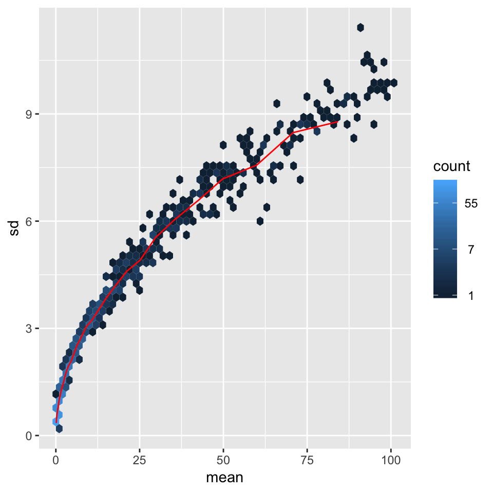

```r
lambda <- 10^seq(from = -1, to = 2, length = 1000)
cts <- matrix(rpois(1000*100, lambda), ncol = 100)
library("vsn")
meanSdPlot(cts, ranks = FALSE)
```

And for logarithm-transformed counts:

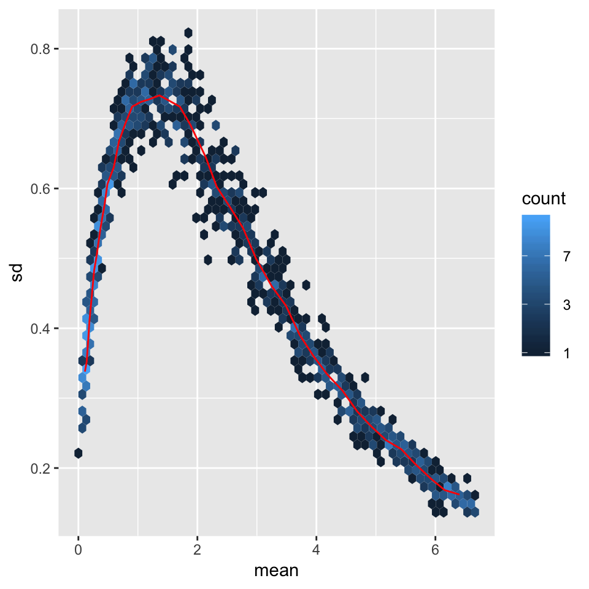

```r
log.cts.one <- log2(cts + 1)
meanSdPlot(log.cts.one, ranks = FALSE)
```

当值近似于0时，一个小的伪数值的对数会使差异增大。具有低信噪比的低计数基因将过度影响 样品 - 样品距离和PCA图。

为了解决这个问题， *DESeq2* 为计数数据提供了两个转换方法来稳定平均值的方差： the *variance stabilizing transformation* (VST) for negative binomial data with a dispersion-mean trend (Anders and Huber 2010), implemented in the *vst* function, and the *regularized-logarithm transformation* or *rlog* (Love, Huber, and Anders 2014).

对于有大计数值的基因，VST和rlog对一般的均一化计数值的log2转换有相似作用。然而，对于 低计数值的基因，值会趋向于中间值。之后VST或者rlog-transformed数据会变成近似的同方差 （more flat trend in the *meanSdPlot*），可以直接用来计算样本间的距离，画PCA图， 或者作为下游的会用到同方差数据的方法的输入。

**Which transformation to choose?** VST的计算速度要快得多，并且对高计数异常值的敏感度低于rlog。rlog在小数据集（n < 30） 上工作得更好，当存在跨样本的大范围的测序深度时，可能会优于VST（一个数量级的差异）。 因此我们推荐在中到大的数据集（n > 30）上使用VST。你也可以两个转换方法都用，比较 生成的 `meanSdPlot` 或PCA图，就像下面描述的那样。

注意，DESeq2提供的两个转换方法是为差异测试以外的应用 *other* 提供的。 对于差异测试，我们推荐使用适用于原始计数值的 *DESeq* 函数，像本工作流程后面描述的那样， 该函数也考虑到了在离差估算步骤中计数值的方差对于平均值的依赖。

*vst* 和 *rlog* 都会返回一个基于 *SummarizedExperiment* 类的 *DESeqTransform* 对象。转换后的值不再是计数值，并存储于 *assay* 插槽中。附加在 `dds` 的 *colData* 仍然 是可以存取的。

```r
vsd <- vst(dds, blind = FALSE)
head(assay(vsd), 3)
```

```
##                 SRR1039508 SRR1039509 SRR1039512 SRR1039513 SRR1039516
## ENSG00000000003   9.742074   9.430420   9.867627   9.645845  10.183143
## ENSG00000000419   9.333669   9.581707   9.486145   9.523093   9.427283
## ENSG00000000457   8.765274   8.698449   8.651473   8.732426   8.592787
##                 SRR1039517 SRR1039520 SRR1039521
## ENSG00000000003   9.880416  10.010366   9.639782
## ENSG00000000419   9.574860   9.325999   9.509246
## ENSG00000000457   8.702674   8.761945   8.724101
```

```r
colData(vsd)
```

```
## DataFrame with 8 rows and 10 columns
##            SampleName     cell      dex    albut        Run avgLength
##              <factor> <factor> <factor> <factor>   <factor> <integer>
## SRR1039508 GSM1275862   N61311    untrt    untrt SRR1039508       126
## SRR1039509 GSM1275863   N61311      trt    untrt SRR1039509       126
## SRR1039512 GSM1275866  N052611    untrt    untrt SRR1039512       126
## SRR1039513 GSM1275867  N052611      trt    untrt SRR1039513        87
## SRR1039516 GSM1275870  N080611    untrt    untrt SRR1039516       120
## SRR1039517 GSM1275871  N080611      trt    untrt SRR1039517       126
## SRR1039520 GSM1275874  N061011    untrt    untrt SRR1039520       101
## SRR1039521 GSM1275875  N061011      trt    untrt SRR1039521        98
##            Experiment    Sample    BioSample        sizeFactor
##              <factor>  <factor>     <factor>         <numeric>
## SRR1039508  SRX384345 SRS508568 SAMN02422669  1.02364764926706
## SRR1039509  SRX384346 SRS508567 SAMN02422675 0.896166721793923
## SRR1039512  SRX384349 SRS508571 SAMN02422678  1.17948612081678
## SRR1039513  SRX384350 SRS508572 SAMN02422670 0.670053829048202
## SRR1039516  SRX384353 SRS508575 SAMN02422682  1.17767135405022
## SRR1039517  SRX384354 SRS508576 SAMN02422673  1.39903646915342
## SRR1039520  SRX384357 SRS508579 SAMN02422683 0.920778683328161
## SRR1039521  SRX384358 SRS508580 SAMN02422677 0.944514089340919
```

Again, for the *rlog*:

```r
rld <- rlog(dds, blind = FALSE)
head(assay(rld), 3)
```

```
##                 SRR1039508 SRR1039509 SRR1039512 SRR1039513 SRR1039516
## ENSG00000000003   9.385681   9.052599   9.516877   9.285335   9.839093
## ENSG00000000419   8.869611   9.138274   9.036117   9.075296   8.972125
## ENSG00000000457   7.961373   7.881385   7.824075   7.921493   7.751690
##                 SRR1039517 SRR1039520 SRR1039521
## ENSG00000000003   9.530313   9.663260   9.277695
## ENSG00000000419   9.131828   8.861529   9.060906
## ENSG00000000457   7.886441   7.957126   7.912125
```

在上面的函数调用中，我们设置了 `blind = FALSE` ，这意味着细胞系和治疗之间的差异 （设计中的变量）将不会影响预期的方差-均值实验的趋势。实验设计不直接用于转换，仅用 于估计计数中的全局变异量。对于完全的 *unsupervised* 转换，可以设置 `blind = TRUE` （这是默认设置）。

为了展示转换的影响，下图中我们绘制了第一个和第二个样本，第一个简单地使用了 *log2* 函数 （在加了1之后，以避免产生 the log of zero），接着使用了VST和 rlog-transformed的值。 对于 *log2* 途径，我们首先需要估算 *size factors* 来来解释测序深度，然后指定 `normalized=TRUE` 。 测序深度校正在 *vst* 和 *rlog*中是自动完成的。

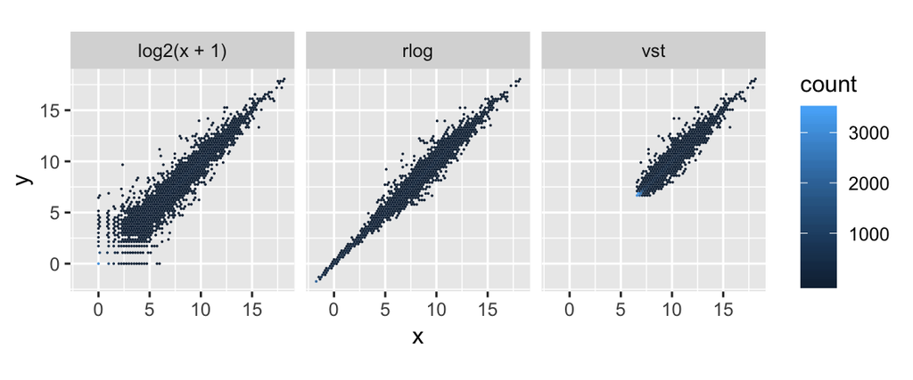

```r
library("dplyr")
library("ggplot2")

dds <- estimateSizeFactors(dds)

df <- bind_rows(
  as_data_frame(log2(counts(dds, normalized=TRUE)[, 1:2]+1)) %>%
         mutate(transformation = "log2(x + 1)"),
  as_data_frame(assay(vsd)[, 1:2]) %>% mutate(transformation = "vst"),
  as_data_frame(assay(rld)[, 1:2]) %>% mutate(transformation = "rlog"))

colnames(df)[1:2] <- c("x", "y")

ggplot(df, aes(x = x, y = y)) + geom_hex(bins = 80) +
  coord_fixed() + facet_grid( . ~ transformation)
```

我们可以看见低计数值的基因（左下角）似乎在正常的对数尺度上变化很大，对于那些在差异表达 上提供了很少信息的数据，VST和rlog压缩了低计数值基因之间的差异。

## 4.3 样本距离

RNA-seq分析一个有效的第一步通常是评估样本之间的整体相似性：哪些样本彼此相似，哪些是不 相似的？这些符合实验设计的期望吗？

我们用R函数 *dist* 来计算样本之间的Euclidean距离。为了确保所有的基因有大致相等的贡献， 我们在VST数据上使用这个函数。我们需要用 *t* 来调换矩阵的值，因为 *dist* 函数期望它的 参数的行是不同的样本，列是不同的dimensions（在这里是基因）。

```r
sampleDists <- dist(t(assay(vsd)))
sampleDists
```

```
##            SRR1039508 SRR1039509 SRR1039512 SRR1039513 SRR1039516 SRR1039517
## SRR1039509   44.08478
## SRR1039512   36.82952   51.50926
## SRR1039513   59.23174   43.11327   47.21641
## SRR1039516   41.08424   54.79377   40.18856   59.72262
## SRR1039517   59.08409   47.46042   54.13979   46.36635   44.74738
## SRR1039520   37.27578   54.00938   34.56797   55.44564   42.81024   58.22766
## SRR1039521   59.26716   42.84573   54.13120   35.24746   60.64298   47.80456
##            SRR1039520
## SRR1039509
## SRR1039512
## SRR1039513
## SRR1039516
## SRR1039517
## SRR1039520
## SRR1039521   48.24754
```

We visualize the distances in a heatmap in a figure below, using the function *pheatmap* from the *pheatmap* package.

```r
library("pheatmap")
library("RColorBrewer")
```

为了绘制样本距离矩阵，行/列按距离矩阵中的距离排列，我们手动地给 *pheatmap* 函数的 `clustering_distance` 参数提供 `sampleDists` 。 否则 *pheatmap* 会假设矩阵包含数据值本身，并且会计算距离矩阵行/列之间的距离，这不是 我们所期望的。 我们也会用手动地指定一个蓝色的调色板 *RColorBrewer* 包中的 *colorRampPalette* 函数。

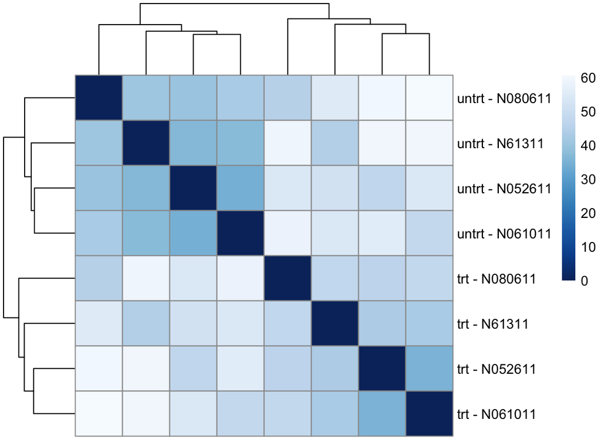

```r
sampleDistMatrix <- as.matrix( sampleDists )
rownames(sampleDistMatrix) <- paste( vsd$dex, vsd$cell, sep = " - " )
colnames(sampleDistMatrix) <- NULL
colors <- colorRampPalette( rev(brewer.pal(9, "Blues")) )(255)
pheatmap(sampleDistMatrix,
         clustering_distance_rows = sampleDists,
         clustering_distance_cols = sampleDists,
         col = colors)
```

另一个计算样本距离的选择是使用 *Poisson Distance* (Witten 2011)， 执行于 *PoiClaClu* 包中。 在计算样本之间的距离时，这种计数值之间的不相似度量也考虑了计数值的固有方差结构。 *PoissonDistance* 函数将样本的原始计数矩阵（未均一化）作为行而不是列，所以我们 需要用 `dds` 调换计数值。

```r
library("PoiClaClu")
poisd <- PoissonDistance(t(counts(dds)))
```

We plot the heatmap in a Figure below.

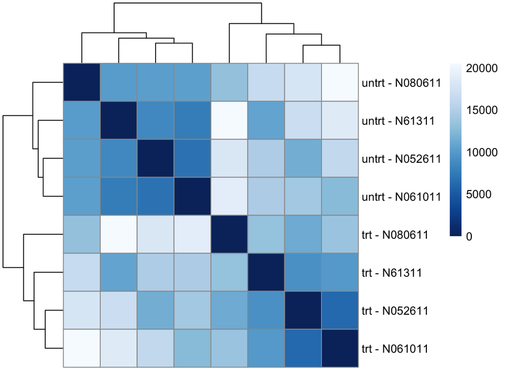

```r
samplePoisDistMatrix <- as.matrix( poisd$dd )
rownames(samplePoisDistMatrix) <- paste( dds$dex, dds$cell, sep=" - " )
colnames(samplePoisDistMatrix) <- NULL
pheatmap(samplePoisDistMatrix,
         clustering_distance_rows = poisd$dd,
         clustering_distance_cols = poisd$dd,
         col = colors)
```

**Heatmap of sample-to-sample distances using the *Poisson Distance*.**

## 4.4 PCA图

另一种可视化样本到样本距离的方式是主成分分析（PCA）。在这种方法中，数据点(这里指样本） 映射到2D平面，他们分散在两个方向上，这能解释大多数的差异（下图所示）。X轴是数据点最多 的方向。这个方向的样本的值被写为 *PC1* 。y轴是数据点第二多方向（it must be *orthogonal* to the first direction）。这个方向的样本的值写为 *PC2* 。 方向中的总差异的百分数打印在坐标轴标签中。注意这个百分比并没有加到100%，因为还有更多的维度中 包含有剩下的差异。（然而剩下的维度中每一个都比我们看到的这两个维度有更少的解释性）。

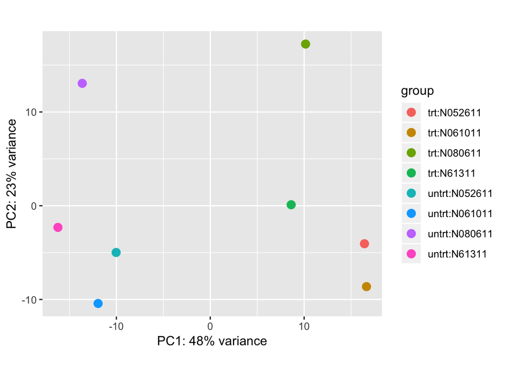

```r
plotPCA(vsd, intgroup = c("dex", "cell"))
```

**PCA plot using the VST data.** 每种之治疗和细胞系的唯一结合都有唯一的颜色。

这里，我们使用了来自 *DESeq2* 的 *plotPCA* 函数。The two terms specified by `intgroup` are the interesting groups for labeling the samples; 它们 告诉函数用它们来选择颜色。我们也能用 *ggplot2*(Wickham 2009) 包从草稿中建立PCA图。 这是通过让 *plotPCA* 函数返回用于画图的数据而不是直接作图来实现的。 关于 *ggplot* 函数的更多细节请参考 *ggplot2* [documentation](http://docs.ggplot2.org/current/)。

```r
pcaData <- plotPCA(vsd, intgroup = c( "dex", "cell"), returnData = TRUE)
pcaData
```

```
##                   PC1         PC2         group   dex    cell       name
## SRR1039508 -16.228435  -2.3110688  untrt:N61311 untrt  N61311 SRR1039508
## SRR1039509   8.618864   0.1055443    trt:N61311   trt  N61311 SRR1039509
## SRR1039512 -10.025968  -4.9857836 untrt:N052611 untrt N052611 SRR1039512
## SRR1039513  16.424047  -4.0524552   trt:N052611   trt N052611 SRR1039513
## SRR1039516 -13.635225  13.0513834 untrt:N080611 untrt N080611 SRR1039516
## SRR1039517  10.153386  17.2437947   trt:N080611   trt N080611 SRR1039517
## SRR1039520 -11.948262 -10.4259788 untrt:N061011 untrt N061011 SRR1039520
## SRR1039521  16.641592  -8.6254361   trt:N061011   trt N061011 SRR1039521
```

```r
percentVar <- round(100 * attr(pcaData, "percentVar"))
```

之后我们可以用这些数据来建立第二张图，如下图所示，图中点的颜色对应地塞米松治疗，点的形状对应 细胞系。

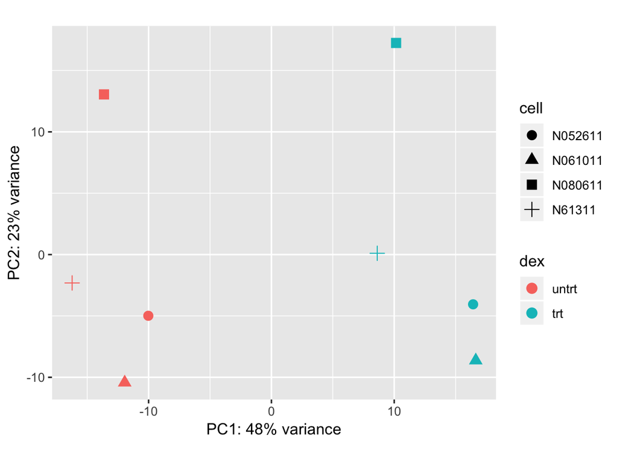

```r
ggplot(pcaData, aes(x = PC1, y = PC2, color = dex, shape = cell)) +
  geom_point(size =3) +
  xlab(paste0("PC1: ", percentVar[1], "% variance")) +
  ylab(paste0("PC2: ", percentVar[2], "% variance")) +
  coord_fixed()
```

**PCA plot using the VST values with custom *ggplot2* code.** 这里我们指定了细胞系（作图符号）和地塞米松治疗（颜色）。

从PCA图中，我们看出不同细胞之间的差异时相当大的（不同的形状），但是地塞米松治疗的 差异更大（红色 VS 蓝色）。这展示了为什么在不同的测试中用一种成对的设计来解释这个 的重要性（“paired”，因为在 *same* 细胞系中每个地塞米松治疗样本都有一个对应的 未治疗的样本）。之前我们已经通过配置公式 `~ cell + dex` 来建立这种设计。

## 4.5 MDS图

另一个和PCA图很相似的图，用基于R的 *multidimensional scaling* (MDS) 函数来制作。 当我们没有数据矩阵，只有距离矩阵时，这个图会很有用。这里我们计算了计算自 *VST* 数据的 距离上的MDS，并将这些画成了下图。

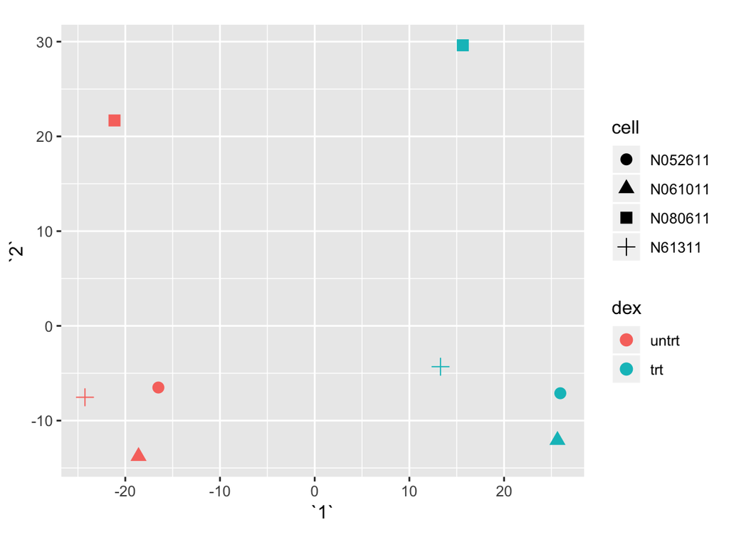

```r
mds <- as.data.frame(colData(vsd))  %>%
         cbind(cmdscale(sampleDistMatrix))
ggplot(mds, aes(x = `1`, y = `2`, color = dex, shape = cell)) +
  geom_point(size = 3) + coord_fixed()
```

**MDS plot using VST data.**

In a figure below we show the same plot for the *PoissonDistance*:

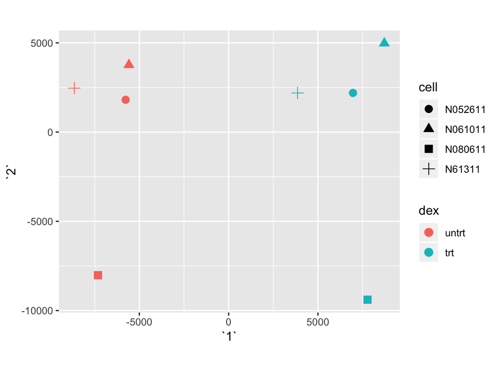

```r
mdsPois <- as.data.frame(colData(dds)) %>%
   cbind(cmdscale(samplePoisDistMatrix))
ggplot(mdsPois, aes(x = `1`, y = `2`, color = dex, shape = cell)) +
  geom_point(size = 3) + coord_fixed()
```

**MDS plot using the *Poisson Distance*.**

# 5 差异表达分析

## 5.1 运行差异表达分析流程

因为我们在创建 *DESeqDataSet* 时早就指定了一个实验设计，我们可以用一个单个的 *DESeq* 函数调用来运行基于原始计数值的差异表达pipeline。

```r
dds <- DESeq(dds)
```

这个函数会打印出它执行的各种步骤的信息。更多细节可以查看手册上有关 *DESeq* 的页面， 您可以通过 `?DESeq` 来到达。主要是：尺寸因子的估算（样本测序深度的差异控制），每个 基因的离散值的估算，以及拟合广义线性模型。

一个 *DESeqDataSet* 会被返回，其中包含所有的拟合参数，以下部分描述了如何从该对象 中提取出感兴趣的结果表格。

## 5.2 建立结果表格

不带参数的调用 *results* 会生成设计规范中的最后一个变量的估计的log2倍数变化值 以及 *p* 值。如果这个变量有超过2个水平，那么 *results* 函数会生成一个结果表格以比较 后一个水平和前一个水平，其会在输出的顶部打印出来：`dex trt vs untrt` 。

```r
res <- results(dds)
res
```

```
## log2 fold change (MLE): dex trt vs untrt
## Wald test p-value: dex trt vs untrt
## DataFrame with 29391 rows and 6 columns
##                          baseMean      log2FoldChange             lfcSE
##                         <numeric>           <numeric>         <numeric>
## ENSG00000000003  708.602169691234  -0.381253887429316 0.100654430187038
## ENSG00000000419  520.297900552084   0.206812715390385 0.112218674572541
## ENSG00000000457  237.163036796015  0.0379205923945968 0.143444716340173
## ENSG00000000460  57.9326331250967 -0.0881676962637897 0.287141995230742
## ENSG00000000938 0.318098378392895     -1.378233965407  3.49987526565862
## ...                           ...                 ...               ...
## ENSG00000273485  1.28644765243289  -0.127098087720873  1.60042118107398
## ENSG00000273486  15.4525365439045  -0.150988513292619 0.486499370223247
## ENSG00000273487   8.1632349843654    1.04640806907172 0.698967253900779
## ENSG00000273488  8.58447903624707   0.107831134309983 0.638099483385527
## ENSG00000273489 0.275899382507797    1.48372584344306  3.51394515550545
##                                stat               pvalue                padj
##                           <numeric>            <numeric>           <numeric>
## ENSG00000000003   -3.78775069036569 0.000152017272634607 0.00128121723830778
## ENSG00000000419    1.84294384315417   0.0653372100766968   0.196207903558091
## ENSG00000000457   0.264356843264061    0.791504963002084   0.911194055629062
## ENSG00000000460  -0.307052600205483    0.758803335537906   0.894634203883442
## ENSG00000000938   -0.39379516719652    0.693732272741941                  NA
## ...                             ...                  ...                 ...
## ENSG00000273485 -0.0794153996609706    0.936702220169112                  NA
## ENSG00000273486  -0.310357058064294    0.756289445616056   0.893661169189343
## ENSG00000273487    1.49707738557415    0.134373123316846   0.329056883636817
## ENSG00000273488   0.168987966794565    0.865806106383284    0.94518264611909
## ENSG00000273489   0.422239328669782    0.672850337762335                  NA
```

我们可以使用以下更具体的命令等效地生成此结果表。由于 `dex` 是设计的最后一个变量，我们可以 选择省略 `contrast` 来生成 `dex` 的两个水平的比较。

```r
res <- results(dds, contrast=c("dex","trt","untrt"))
```

As `res` is a *DataFrame* object, it carries metadata with information on the meaning of the columns:

```r
mcols(res, use.names = TRUE)
```

```
## DataFrame with 6 rows and 2 columns
##                        type                               description
##                 <character>                               <character>
## baseMean       intermediate mean of normalized counts for all samples
## log2FoldChange      results  log2 fold change (MLE): dex trt vs untrt
## lfcSE               results          standard error: dex trt vs untrt
## stat                results          Wald statistic: dex trt vs untrt
## pvalue              results       Wald test p-value: dex trt vs untrt
## padj                results                      BH adjusted p-values
```

第一列， `baseMean` 是归一化的计数值的平均值, 由尺寸因子划分开，取自 *DESeqDataSet* 的所有样本。 其他四列指特定的对比，即因子变量 `dex` 的 `trt` 水平与 `untrt` 的对比。下面我们会 阐明如何获得其他的对比。

`log2FoldChange` 列是效应大小估计。它是指地塞米松治疗样本与不治疗样本对比，有多少基因 表达改变了。这个值是一个以2为底的log值：例如，a log2 fold change of 1.5意思是基因 表达增加了，by a multiplicative factor of $2^{1.5} \approx 2.82$。

当然，这个估计值有一个与之相关的不确定性，可以在 `lfcSE` 列中找到，这是log2 fold change 的标准差估计。作为统计检验的结果，我们还可以表示特定效应大小估计的不确定性。对差异表达进行 检验的目的是确定数据是否有足够的证据证明值与0有差异。*DESeq2* 为每个基因执行 *hypothesis test* 以确定是否有足够证据来推翻 *null hypothesis* ，这个无效检验是指治疗对基因是没有影响的，现在观察 到的治疗组与对照组之间的差异只是实验的可变性造成的。（即在同一个治疗组里你可以预期的不同样本间的 变异性的类型）。通常在统计中，这种检验的结果是用 *p* 值来表示的，即fold change与观察到的一样强或者 更强的可能性，将在无效假设描述的情况下看到。

我们还可以使用以下代码行汇总结果，这些代码会报告一些其他信息，这些信息将在后面的章节中介绍。

```r
summary(res)
```

```
##
## out of 29391 with nonzero total read count
## adjusted p-value < 0.1
## LFC > 0 (up)       : 2607, 8.9%
## LFC < 0 (down)     : 2218, 7.5%
## outliers [1]       : 0, 0%
## low counts [2]     : 11397, 39%
## (mean count < 5)
## [1] see 'cooksCutoff' argument of ?results
## [2] see 'independentFiltering' argument of ?results
```

注意在FDR水平为10%的情况下，地塞米松治疗会造成许多基因的差异表达。这是说得通的，因为已知气道 的平滑肌细胞会与糖皮质激素起反应。然而，有两种方法更严格的确定哪一组基因更重要：

- 降低错误发现率的阈值 (有关 `padj` 的临界值)
- 用 *results* 的 `lfcThreshold` 参数来从0提高log2倍数变化的阈值

如果我们降低错误发现率的阈值，我们也要将其报给 `results()` 函数，这样该函数就能用这个阈值来 进行最佳的independent filtering：

```r
res.05 <- results(dds, alpha = 0.05)
table(res.05$padj < 0.05)
```

```
##
## FALSE  TRUE
## 12829  4026
```

如果我们想提高log2倍数变化的阈值，以便检验由于治疗而展现出更大变化的基因，我们可以简单的给 log2 scale补充一个值。例如，通过指定 `lfcThreshold = 1` ，我们对在治疗中表现出显著影响 的基因在数量上的检验会翻倍或减少一半，因为 $2^1 = 2$。

```r
resLFC1 <- results(dds, lfcThreshold=1)
table(resLFC1$padj < 0.1)
```

```
##
## FALSE  TRUE
## 20034   240
```

有时候 `res` 中的 *p* 值的子集会是 `NA` （没有得到）。这是 *DESeq* 中报告这个基因的所有 计数值都是0的方式，因此不会应用任何检验。 此外，如果基因由于包含一个极端的异常值而被剔除出分 析，那么 *p* 值也会是 `NA` 。更多信息请参考 *DESeq2* 简介中有关异常值检测的部分。

如果你将源自一个R分析包的结果用在公开的研究中，你可以通过键入`citation("pkgName")` 来找到 这个软件的特定引用格式，你要用包的名字来替换 `pkgName`。引用方法文献有助于支持和嘉奖那些为了 基因组数据分析的开源软件花了大量时间的人。

## 5.3 其他比较

总之，一个变量导入任何两个水平之间的比较结果可以用 *results* 的 `contrast` 参数提取到。 用户要指定3个值：变量的名字，分子上的水平的名字以及分母上的水平的名字。这里我们提取了两个 细胞系之间的log2倍数变化的结果：

```r
results(dds, contrast = c("cell", "N061011", "N61311"))
```

```
## log2 fold change (MLE): cell N061011 vs N61311
## Wald test p-value: cell N061011 vs N61311
## DataFrame with 29391 rows and 6 columns
##                          baseMean      log2FoldChange             lfcSE
##                         <numeric>           <numeric>         <numeric>
## ENSG00000000003  708.602169691234   0.306326362739978 0.143530866244254
## ENSG00000000419  520.297900552084 -0.0540467035087685 0.159716090785554
## ENSG00000000457  237.163036796015  0.0163084038114845  0.20302595697949
## ENSG00000000460  57.9326331250967   0.279127044592995 0.400667397006202
## ENSG00000000938 0.318098378392895                   0   4.9975798104491
## ...                           ...                 ...               ...
## ENSG00000273485  1.28644765243289   -2.32141260766577  2.35291638140544
## ENSG00000273486  15.4525365439045 -0.0727157623832583 0.711890912073144
## ENSG00000273487   8.1632349843654 -0.0269346906402043  1.00507452886325
## ENSG00000273488  8.58447903624707    1.09584759066512 0.898948246150508
## ENSG00000273489 0.275899382507797                   0   4.9975798104491
##                                stat             pvalue              padj
##                           <numeric>          <numeric>         <numeric>
## ENSG00000000003     2.1342194244037 0.0328248233823354 0.214730145872796
## ENSG00000000419  -0.338392351346335  0.735067537267948 0.935493501438616
## ENSG00000000457   0.080326693463792  0.935977428491716 0.989390053166377
## ENSG00000000460   0.696655247416285  0.486018572065081 0.846163823311993
## ENSG00000000938                   0                  1                NA
## ...                             ...                ...               ...
## ENSG00000273485  -0.986610755066082  0.323833495704889                NA
## ENSG00000273486  -0.102144529660448  0.918641956272754 0.985420987200884
## ENSG00000273487 -0.0267986998642455  0.978620290204838                NA
## ENSG00000273488    1.21903301481234  0.222831662001976                NA
## ENSG00000273489                   0                  1                NA
```

在运行了 *DESeq* 一次后，还有一些其他的方法来为某些比较建立结果表格。 如果需要交互项的结果，那么要使用 *results* 的 `name` 参数。请参考 *results* 函数的帮主页面以获取更多有关用其他方式来建立结果表格的详细信息。尤其是 *results* 帮主页面的 **Examples** 部分给出了几个很中肯的例子。

## 5.4 多重检验

在高通量生物学中，我们不要直接用 *p* 值来否定无效假设，而要用 *multiple testing* 来进行校正。如果我们简单地将 *p* 值的临界值设定为一个比较低的值会怎样，比如0.05？ 在检验中成功报告了一个 *p* 值的 29391 基因中会存在 *p* 值低于0.05的5677 基因：

```r
sum(res$pvalue < 0.05, na.rm=TRUE)
```

```
## [1] 5677
```

```r
sum(!is.na(res$pvalue))
```

```
## [1] 29391
```

*DESeq2* 使用基础R函数中实现的 the Benjamini-Hochberg (BH) adjustment (Benjamini and Hochberg 1995)。简言之，这个方法为每个基因计算一个调整过的 *p* 值，该值回答了以下问题：如果一个被调用的显著的所有基因的调整后的 *p* 值小于或 等于这个基因的调整后 *p* 值的阈值，在此意义上的假阳性（the *false discovery rate*, FDR） 的比例是多少？这些值，被叫做BH-adjusted *p* values，在 `res` 列的 `padj` 列中给出。

FDR在很多的高通量实验的统计中都很有用，因为我们经常感兴趣于报告或聚焦于一组有趣的基因， 因此我们想要给这组的假阳性百分比设置一个上限。

因此，如果我们考虑10%的假阳性率是可以接受的，那么我们认为所有的调整后的 *p* 小于0.1 的基因都是显著的。这样的基因有多少呢？

```r
sum(res$padj < 0.1, na.rm=TRUE)
```

```
## [1] 4825
```

我们对结果表格中的这些基因取子集，然后按照log2倍数变化值进行排序，从而获得下调得最多 的显著基因：

```r
resSig <- subset(res, padj < 0.1)
head(resSig[ order(resSig$log2FoldChange), ])
```

```
## log2 fold change (MLE): dex trt vs untrt
## Wald test p-value: dex trt vs untrt
## DataFrame with 6 rows and 6 columns
##                         baseMean    log2FoldChange             lfcSE
##                        <numeric>         <numeric>         <numeric>
## ENSG00000128285 6.62474139908411 -5.32590514755406  1.25781646244798
## ENSG00000267339 26.2335725682209 -4.61155039131948 0.673094468700225
## ENSG00000019186 14.0876049307722 -4.32590664693342 0.857767767163719
## ENSG00000183454 5.80417114112773 -4.26407747502168  1.16687734166995
## ENSG00000146006 46.8075965458274  -4.2118502375277 0.528851947804937
## ENSG00000141469 53.4365283575179 -4.12478447879794   1.1297976633824
##                              stat               pvalue                 padj
##                         <numeric>            <numeric>            <numeric>
## ENSG00000128285 -4.23424665406963 2.29319143028289e-05  0.00023755720550668
## ENSG00000267339 -6.85126769831371 7.31983899180918e-12 2.04841652906088e-10
## ENSG00000019186 -5.04321427376246  4.5777613182453e-07 6.60462531203733e-06
## ENSG00000183454 -3.65426366829546 0.000257921111014126  0.00204722065415288
## ENSG00000146006 -7.96413864978561 1.66378621897173e-15 7.14247557421898e-14
## ENSG00000141469 -3.65090547846338 0.000261317404823323  0.00206960624224951
```

…and with the strongest up-regulation:

```r
head(resSig[ order(resSig$log2FoldChange, decreasing = TRUE), ])
```

```
## log2 fold change (MLE): dex trt vs untrt
## Wald test p-value: dex trt vs untrt
## DataFrame with 6 rows and 6 columns
##                         baseMean   log2FoldChange             lfcSE
##                        <numeric>        <numeric>         <numeric>
## ENSG00000179593 67.2430476358842 9.50597241247416  1.05450220396068
## ENSG00000109906 385.071028862516 7.35262793318718 0.536390220039323
## ENSG00000250978 56.3181939282226  6.3273837397078 0.677797382672816
## ENSG00000132518 5.65465445433956 5.88511165460784  1.32404324478884
## ENSG00000127954 286.384119280247 5.20716032804828 0.493082760580173
## ENSG00000249364 8.83906075961539 5.09810727071616  1.15961389777208
##                             stat               pvalue                 padj
##                        <numeric>            <numeric>            <numeric>
## ENSG00000179593 9.01465390662063 1.97493059046227e-19 1.25129933256261e-17
## ENSG00000109906 13.7076099796304 9.14198752722158e-43 2.25343730910719e-40
## ENSG00000250978 9.33521418267579 1.00787266738981e-20 7.19669078452868e-19
## ENSG00000132518 4.44480320244103 8.79723586811642e-06 9.98722159059223e-05
## ENSG00000127954 10.5604185429671 4.54630170772714e-26 5.04976252647174e-24
## ENSG00000249364 4.39638338287508 1.10069452799683e-05 0.000122258625535648
```

# 6 结果绘图

## 6.1 计数值绘图

要可视化一个特定基因的计数值，最快的方法是用 *plotCounts* 函数，该函数将 *DESeqDataSet* ，基因的名字，以及用于画图的组作为参数（下图）。

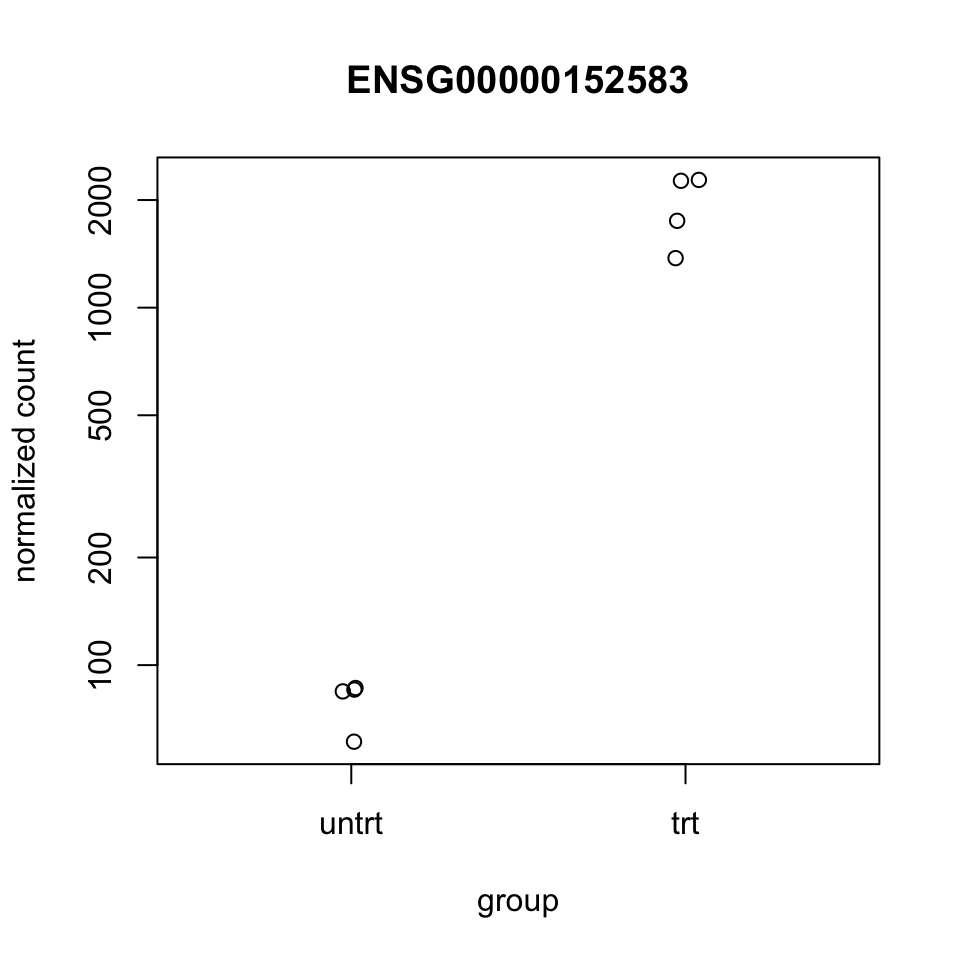

```r
topGene <- rownames(res)[which.min(res$padj)]
plotCounts(dds, gene = topGene, intgroup=c("dex"))
```

**Normalized counts for a single gene over treatment group.**

我们也可以用 *ggplot2* 包的 *ggplot* 函数来定制图（下图）。

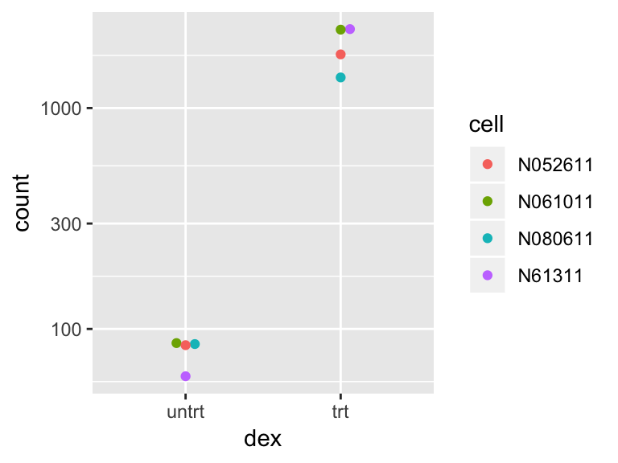

```r
library("ggbeeswarm")
geneCounts <- plotCounts(dds, gene = topGene, intgroup = c("dex","cell"),
                         returnData = TRUE)
ggplot(geneCounts, aes(x = dex, y = count, color = cell)) +
  scale_y_log10() +  geom_beeswarm(cex = 3)
```

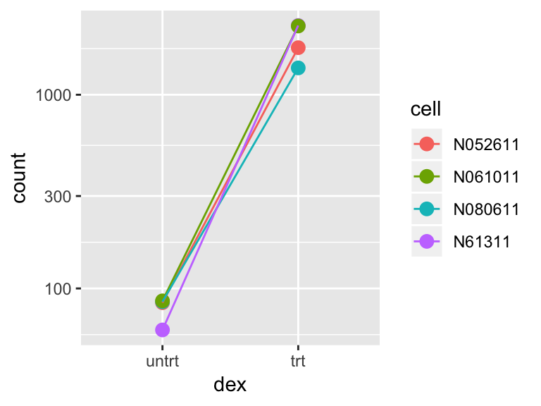

```r
ggplot(geneCounts, aes(x = dex, y = count, color = cell, group = cell)) +
  scale_y_log10() + geom_point(size = 3) + geom_line()
```

**Normalized counts with lines connecting cell lines.** 注意到 *DESeq* 检验实际上考虑到了细胞系的影响，所以这个图更准确的描绘了检验的差异。

## 6.2 MA图

*MA-plot* 提供了模型的估计系数分布情况的有用的概览，e.g. the comparisons of interest, across all genes. 在Y轴上，“M”代表“minus”– subtraction of log values is equivalent to the log of the ratio – 在X轴上，“A”代表“average”，你可能也听说过此图也成为mean-difference图或者 Bland-Altman图。

在绘制MA-plot之前，我们使用 *lfcShrink* 函数来缩减地塞米松治疗样本和未治疗样本之间的 log2倍数差异。 *DESeq2* 中有3种类型的缩减器，详见[DESeq2 vignette](https://bioconductor.org/packages/release/bioc/vignettes/DESeq2/inst/doc/DESeq2.html)。 这里我们制定 *apeglm* 方法来缩减系数，其善于缩减嘈杂的LFC估计值，同时为非常大的差异给出 低偏差的LFC估计值(Zhu, Ibrahim, and Love 2018)。要使用 *apeglm* ，我们可以通过名字或序号来指定一个模型 中的收缩系数，因为系数出现在 `resultsNames(dds)` 中。

```r
library("apeglm")
resultsNames(dds)
```

```
## [1] "Intercept"               "cell_N061011_vs_N052611"
## [3] "cell_N080611_vs_N052611" "cell_N61311_vs_N052611"
## [5] "dex_trt_vs_untrt"
```

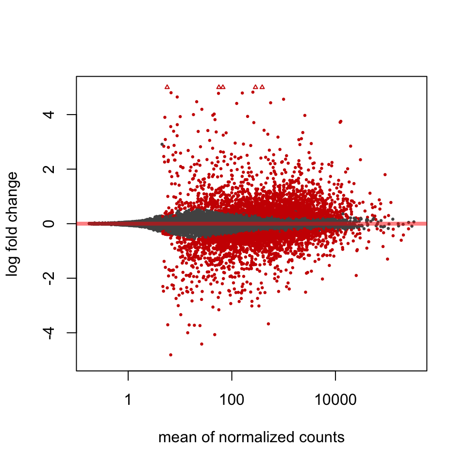

```r
res <- lfcShrink(dds, coef="dex_trt_vs_untrt", type="apeglm")
plotMA(res, ylim = c(-5, 5))
```

如果要指定 `resultsNames(dds)` 中没有的对比度，可以使用其他的两种收缩方法的任一种， 或者在某些情况下，重构相关的变量，然后运行 `nbinomWaldTest` 再运行 `lfcShrink` 就可以了。更多细节请参考DESeq2简介。

**An MA-plot of changes induced by treatment.** 特定比较间的log2倍数变化绘制在Y轴，经尺寸系数标准化的计数值的均值展现在X轴。 每个点代表一个基因。调整后的 *p* 值小于临界值（这里是0.1，默认的）的基因，显示 为红色。

*DESeq2* 包使用贝叶斯程序来缓和（或缩减）极低计数值且计数值差异巨大的基因的 log2倍数变化，通过缩小MA-plot左侧点的垂直扩展可以看出。如上所示， *lfcShrink* 函数执行这个操作。 关于缓和倍数变化的原理的更详细解释，请参见 *DESeq2* 页面(Love, Huber, and Anders 2014)。

如果我们没有用统计调节来缩减嘈杂的log2倍数变化，我们可能会看到下图：

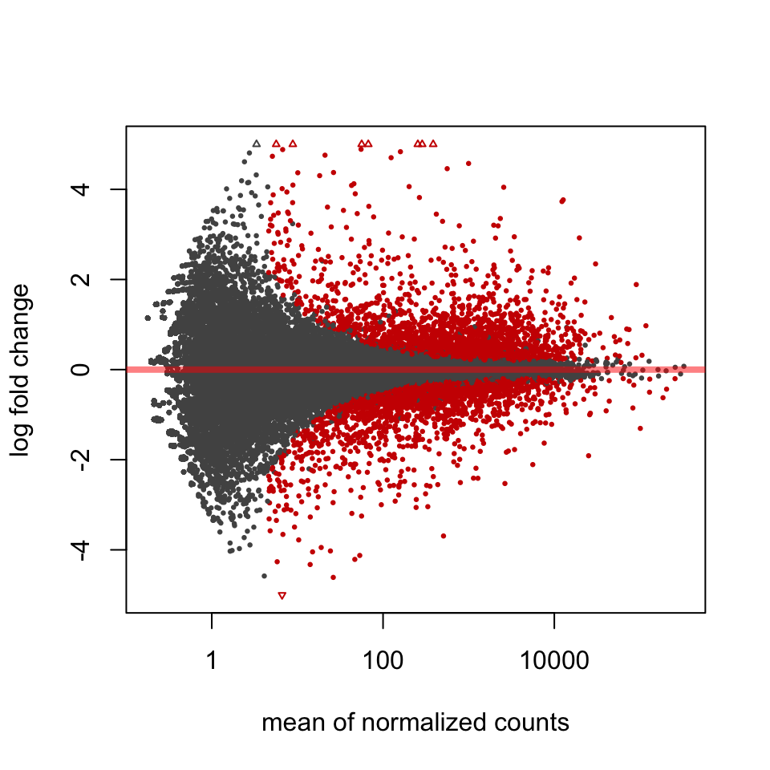

```r
res.noshr <- results(dds, name="dex_trt_vs_untrt")
plotMA(res.noshr, ylim = c(-5, 5))
```

我们也可以标记MA-plot上的各个点。这里我们使用了R函数 *with* 来给结果对象的选定行 绘制圈和文字。在 *with* 函数中， `res` 的选定行中只有 `baseMean` 和`log2FoldChange` 值会被用到。

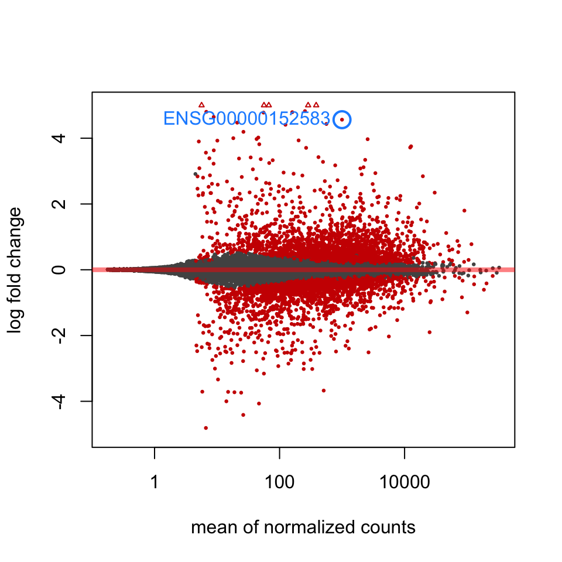

```r
plotMA(res, ylim = c(-5,5))
topGene <- rownames(res)[which.min(res$padj)]
with(res[topGene, ], {
  points(baseMean, log2FoldChange, col="dodgerblue", cex=2, lwd=2)
  text(baseMean, log2FoldChange, topGene, pos=2, col="dodgerblue")
})
```

另一个很有用的诊断图是 *p* 值的直方图（下图）。最好在此图中去掉极小计数值的基因， 否则会在直方图中产生峰值。

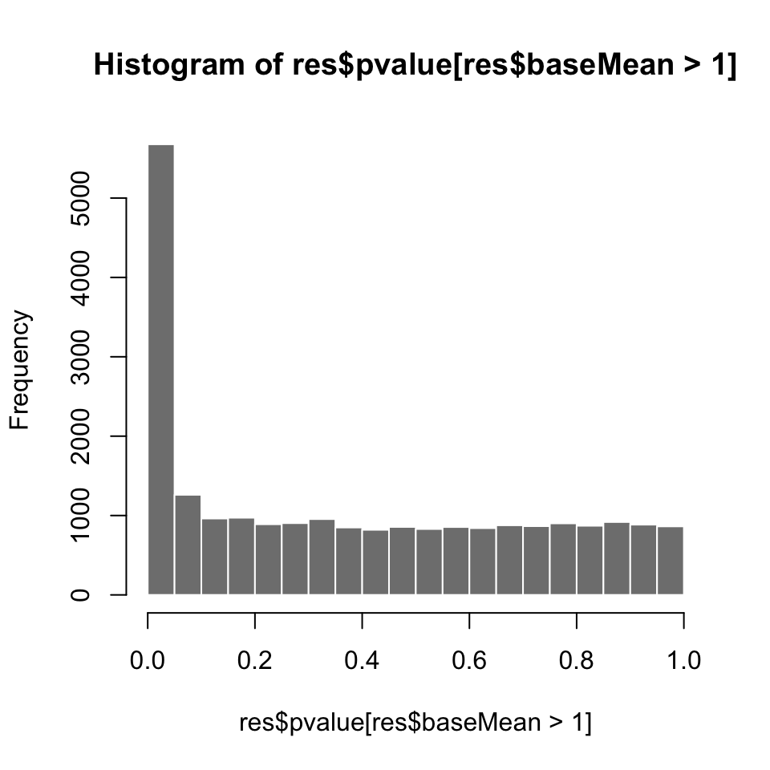

```r
hist(res$pvalue[res$baseMean > 1], breaks = 0:20/20,
     col = "grey50", border = "white")
```

**Histogram of *p* values for genes with mean normalized count larger than 1.**

## 6.3 基因聚类

在前面做的样本距离的热图中，边上的系统发育树展示了样本的分层聚类。这样的聚类也可以用在 基因上。由于聚类只与实际携带信号的基因有关，因此通常只聚类变化性最大的那些基因。这里， 作为展示，我们选取了跨样本的20个变化最大的基因。我们用VST数据来操作。

```r
library("genefilter")
topVarGenes <- head(order(rowVars(assay(vsd)), decreasing = TRUE), 20)
```

如果我们不考虑样本的绝对表达强度而是考虑相对所有样本中基因的平均值，每个基因在特定样本 中偏离的量，那么热图会变得更有趣。因此，我们将跨样本的每个基因集中，绘制热图（下图）。 我们提供 *data.frame* 来指导 *pheatmap* 函数如何给每一列打标签。

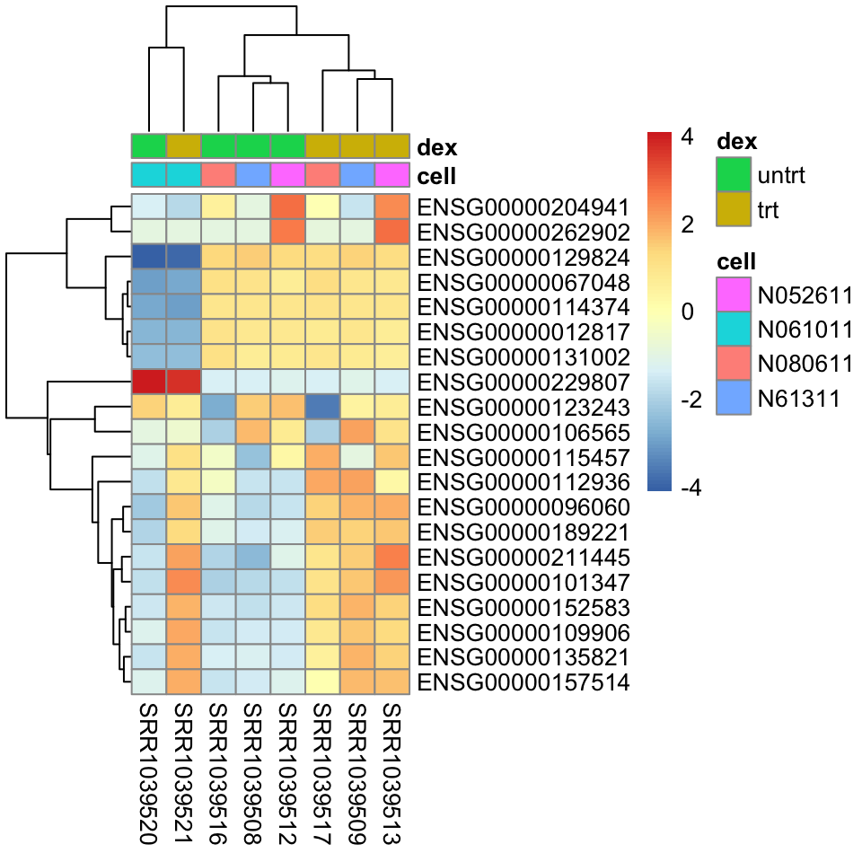

```r
mat  <- assay(vsd)[ topVarGenes, ]
mat  <- mat - rowMeans(mat)
anno <- as.data.frame(colData(vsd)[, c("cell","dex")])
pheatmap(mat, annotation_col = anno)
```

**Heatmap of relative VST-transformed values across samples.** 治疗状态和细胞系信息显示在热图顶部的彩色条。跨病人的基因块。注意热图顶部的一组 基因将N061011细胞系和其他细胞系分离开。在热图的中心，我们看到了一组用地塞米松 治疗的样本，她们有更高的基因表达。

## 6.4 独立性检验

MA图突出了RNA-seq数据的一个重要属性。对于微弱表达的基因，我们很难观察其差异表达情况， 因为低reads计数值遭受了非常高的泊松噪声，以至于任何的生物效应都会在低采样率的 不确定性中被淹没。我们也可以通过检测经过平均归一化计数值打包的基因的小 *p* 值 （小于0.05）的比率来展示这个。我们将使用经受临界值的结果表格来展示在几乎没有小 *p* 值检验的情况下这个看起来像什么。

在下面的代码块中，我们用 *quantile* 生成了一个容器，使用 *cut* 通过基本均值来 封装基因，用中点重命名容器的水平，计算每个容器 *p* 值小于0.05的比率，最后画出这 些比率（下图）。

[figure not shown]

```r
qs <- c(0, quantile(resLFC1$baseMean[resLFC1$baseMean > 0], 0:6/6))
bins <- cut(resLFC1$baseMean, qs)
levels(bins) <- paste0("~", round(signif((qs[-1] + qs[-length(qs)])/2, 2)))
fractionSig <- tapply(resLFC1$pvalue, bins, function(p)
                          mean(p < .05, na.rm = TRUE))
barplot(fractionSig, xlab = "mean normalized count",
                     ylab = "fraction of small p values")
```

**The ratio of small *p* values for genes binned by mean normalized count.** *p* 值来源于一个log2倍数变化大于1或小于1的检验。这个图表明，平均计数非常低的基因没有或 有很少的效能，最好从检验中排除。

咋一看，过滤这些基因似乎没有什么好处。毕竟，检验会会发现它们没有显著性。然而，这些基因会 对多重检验调整有影响，如果过滤这些基因，表现会提高。在FDR程序中的输入中移除的低计数值的 基因，我们能在我们保留的基因中发现更多的基因有显著性，从而能提高检验的效能。该途径用 *independent filtering* 实现。

*independent* 这个术语强调了一个重要的警告。只有当我们过滤的统计量（这里是所有样本的 归一化技术值的均值）不依赖于无效假设下的实际检验的统计量（ *p* 值），这种过滤才是被 允许的。否则，过滤会导致检验无效，最终导致BH过程的假设无效。 independent filtering软件使用 *genefilter* 包中的 *DESeq2* ， 其中包含一个描述independent filtering的统计学基础的参考文献 (Bourgon, Gentleman, and Huber 2010)。

# 7 注释及结果导出

目前为止，我们的结果表格中只包含Ensembl基因的ID，但是替之以基因名能为解释提供更多的信息。 Bioconductor 的注释包用于不同的ID格式间的彼此映射。 We load the *AnnotationDbi* package and the annotation package *org.Hs.eg.db*:

```r
library("AnnotationDbi")
library("org.Hs.eg.db")
```

这个是用于 *Homo sapiens* (“Hs”) 的生物体注释包，rganized as an *AnnotationDbi* database package (“db”), using Entrez Gene IDs (“eg”) as primary key. 要获得全部可获取的键的类型列表，使用：

```r
columns(org.Hs.eg.db)
```

```
##  [1] "ACCNUM"       "ALIAS"        "ENSEMBL"      "ENSEMBLPROT"
##  [5] "ENSEMBLTRANS" "ENTREZID"     "ENZYME"       "EVIDENCE"
##  [9] "EVIDENCEALL"  "GENENAME"     "GO"           "GOALL"
## [13] "IPI"          "MAP"          "OMIM"         "ONTOLOGY"
## [17] "ONTOLOGYALL"  "PATH"         "PFAM"         "PMID"
## [21] "PROSITE"      "REFSEQ"       "SYMBOL"       "UCSCKG"
## [25] "UNIGENE"      "UNIPROT"
```

我们可以使用 *mapIds* 函数来给我们的结果表格中添加个人的列。我们将结果表中的行名作为键， 并且指定 `keytype=ENSEMBL`。 `column` 参数告诉 *mapIds* 函数我们想要那个信息，并且 `multiVals` 参数告诉函数如果单个的输入值有多个可能的值时应该怎么做。这里我们只要要求 返回给我们表格中的第一个。 为了添加 gene symbol和Entrez ID，我们调用 *mapIds* 两次。

```r
res$symbol <- mapIds(org.Hs.eg.db,
                     keys=row.names(res),
                     column="SYMBOL",
                     keytype="ENSEMBL",
                     multiVals="first")
res$entrez <- mapIds(org.Hs.eg.db,
                     keys=row.names(res),
                     column="ENTREZID",
                     keytype="ENSEMBL",
                     multiVals="first")
```

Now the results have the desired external gene IDs:

```r
resOrdered <- res[order(res$pvalue),]
head(resOrdered)
```

```
## log2 fold change (MAP): dex trt vs untrt
## Wald test p-value: dex trt vs untrt
## DataFrame with 6 rows and 7 columns
##                         baseMean   log2FoldChange             lfcSE
##                        <numeric>        <numeric>         <numeric>
## ENSG00000152583 997.439773207048 4.56334706475901 0.185619897835832
## ENSG00000165995 495.092906698546 3.28035231082946 0.133330866932628
## ENSG00000120129 3409.02937530956 2.93799351420719  0.12202777083291
## ENSG00000101347 12703.3870621821 3.75352539563574  0.15705353372166
## ENSG00000189221 2341.76725275591  3.3421864346776 0.143093947297795
## ENSG00000211445 12285.6151498691  3.7169519696876 0.167889677029247
##                                pvalue                  padj      symbol
##                             <numeric>             <numeric> <character>
## ENSG00000152583 2.22231974839155e-136 3.99884215525576e-132     SPARCL1
## ENSG00000165995  7.8397572087114e-135 7.05342956067765e-131      CACNB2
## ENSG00000120129 3.66732005915504e-130 2.19965857148119e-126       DUSP1
## ENSG00000101347 9.56353875785341e-130 4.30215791022035e-126      SAMHD1
## ENSG00000189221 1.09937074996403e-123 3.95641545497056e-120        MAOA
## ENSG00000211445 4.61813781939102e-112 1.38497953203537e-108        GPX3
##                      entrez
##                 <character>
## ENSG00000152583        8404
## ENSG00000165995         783
## ENSG00000120129        1843
## ENSG00000101347       25939
## ENSG00000189221        4128
## ENSG00000211445        2878
```

## 7.1 结果导出

您可以轻松地将结果表保存在CSV文件中，然后可以使用Excel等电子表格程序共享或加载该文件。 您需要调用 *as.data.frame* 函数来将 *DataFrame* 对象（*IRanges* 包） 转换成能被 *write.csv* 函数处理的 *data.frame* 对象。这里，我们只用了100个基因来展示。

```r
resOrderedDF <- as.data.frame(resOrdered)[1:100, ]
write.csv(resOrderedDF, file = "results.csv")
```

一个更完整的导出结果的方法是Bioconductor包 *ReportingTools* (Huntley et al. 2013)。 *ReportingTools* 会自动地产生动态HTML文件，包括使用gene identifiers的外部数据库链接， 以及归纳了不同样本的归一化计数值的箱线图。更多细节请参看 *ReportingTools* 简介。最简单的 生成一个动态 *ReportingTools* 报告的版本是执行下面的代码：

```r
library("ReportingTools")
htmlRep <- HTMLReport(shortName="report", title="My report",
                      reportDirectory="./report")
publish(resOrderedDF, htmlRep)
url <- finish(htmlRep)
browseURL(url)
```

## 7.2 绘制基因组空间倍数变化图

如果我们 *summarizeOverlaps* 函数来计数reads，那么我们的 *DESeqDataSet* 对象建立 在指定了基因的基因组坐标的准备使用的Bioconductor对象上面。因而我们可以很容易的在基因组 尺度上画出差异表达结果。 *results* 函数默认返回一个 *DataFrame* ，使用 `format` 参数， 我们产生 *GRanges* 或 *GRangesList* 输出。*lfcShrink* 还没有输出 *GRanges* 的 选项，所以我们手动地添加收缩系数这一列。

```r
resGR <- results(dds, name="dex_trt_vs_untrt", format="GRanges")
resGR$log2FoldChange <- res$log2FoldChange
resGR
```

```
## GRanges object with 29391 ranges and 6 metadata columns:
##                   seqnames              ranges strand |          baseMean
##                      <Rle>           <IRanges>  <Rle> |         <numeric>
##   ENSG00000000003        X   99883667-99894988      - |  708.602169691234
##   ENSG00000000419       20   49551404-49575092      - |  520.297900552084
##   ENSG00000000457        1 169818772-169863408      - |  237.163036796015
##   ENSG00000000460        1 169631245-169823221      + |  57.9326331250967
##   ENSG00000000938        1   27938575-27961788      - | 0.318098378392895
##               ...      ...                 ...    ... .               ...
##   ENSG00000273485       10 105209953-105210609      + |  1.28644765243289
##   ENSG00000273486        3 136556180-136557863      - |  15.4525365439045
##   ENSG00000273487        1   92654794-92656264      + |   8.1632349843654
##   ENSG00000273488        3 100080031-100080481      + |  8.58447903624707
##   ENSG00000273489        7 131178723-131182453      - | 0.275899382507797
##                         log2FoldChange             lfcSE                stat
##                              <numeric>         <numeric>           <numeric>
##   ENSG00000000003   -0.358454116862156 0.100654430187038   -3.78775069036569
##   ENSG00000000419    0.186072582534032 0.112218674572541    1.84294384315417
##   ENSG00000000457   0.0313468235829716 0.143444716340173   0.264356843264061
##   ENSG00000000460  -0.0472622281192214 0.287141995230742  -0.307052600205483
##   ENSG00000000938  -0.0123430869165611  3.49987526565862   -0.39379516719652
##               ...                  ...               ...                 ...
##   ENSG00000273485 -0.00445615114108001  1.60042118107398 -0.0794153996609706
##   ENSG00000273486  -0.0430928317067558 0.486499370223247  -0.310357058064294
##   ENSG00000273487    0.191163980783957 0.698967253900779    1.49707738557415
##   ENSG00000273488   0.0219401136188055 0.638099483385527   0.168987966794565
##   ENSG00000273489   0.0121980339823695  3.51394515550545   0.422239328669782
##                                 pvalue                padj
##                              <numeric>           <numeric>
##   ENSG00000000003 0.000152017272634607 0.00128121723830778
##   ENSG00000000419   0.0653372100766968   0.196207903558091
##   ENSG00000000457    0.791504963002084   0.911194055629062
##   ENSG00000000460    0.758803335537906   0.894634203883442
##   ENSG00000000938    0.693732272741941                <NA>
##               ...                  ...                 ...
##   ENSG00000273485    0.936702220169112                <NA>
##   ENSG00000273486    0.756289445616056   0.893661169189343
##   ENSG00000273487    0.134373123316846   0.329056883636817
##   ENSG00000273488    0.865806106383284    0.94518264611909
##   ENSG00000273489    0.672850337762335                <NA>
##   -------
##   seqinfo: 722 sequences (1 circular) from an unspecified genome
```

We need to add the symbol again for labeling the genes on the plot:

```r
resGR$symbol <- mapIds(org.Hs.eg.db, names(resGR), "SYMBOL", "ENSEMBL")
```

我们将使用 *Gviz* 包来绘制GRanges和相关的metadata：由于地塞米松 治疗产生的log倍数变化。

```r
library("Gviz")
```

以下代码块指定了一个来自最小 *p* 值基因的上游和下游的100万碱基对的窗口。我们为这个 窗口的基因生成了一个完整结果的子集。如果符号存在并且在子集中没有重复，我们将基因 符号添加为名称。

```r
window <- resGR[topGene] + 1e6
strand(window) <- "*"
resGRsub <- resGR[resGR %over% window]
naOrDup <- is.na(resGRsub$symbol) | duplicated(resGRsub$symbol)
resGRsub$group <- ifelse(naOrDup, names(resGRsub), resGRsub$symbol)
```

We create a vector specifying if the genes in this subset had a low value of `padj`.

```r
status <- factor(ifelse(resGRsub$padj < 0.1 & !is.na(resGRsub$padj),
                     "sig", "notsig"))
```

然后我们可以用 *Gviz* 函数来绘制结果（下图）。我们生成了一个axis track 来指定我们在基因组中的坐标，track会显示基因及其名字，按照显著性来着色，同时一个data track 会画出vertical bars来显示用 *DESeq2* 生成的缓和的log倍数变化，这个data track只有在 计数信息很好的支持了效应的时候才会很大。

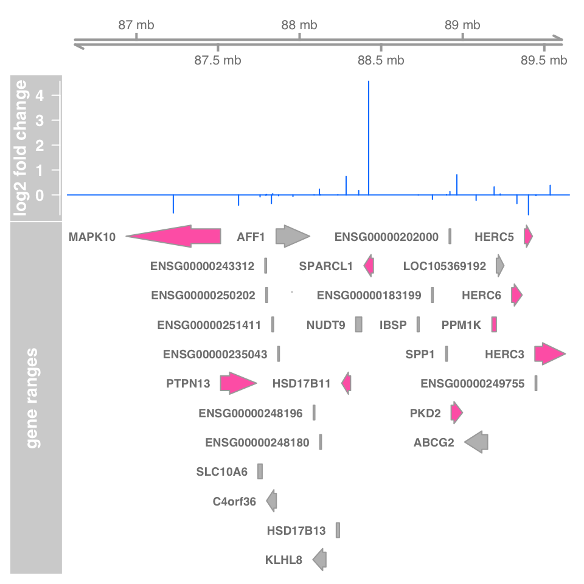

```r
options(ucscChromosomeNames = FALSE)
g <- GenomeAxisTrack()
a <- AnnotationTrack(resGRsub, name = "gene ranges", feature = status)
d <- DataTrack(resGRsub, data = "log2FoldChange", baseline = 0,
               type = "h", name = "log2 fold change", strand = "+")
plotTracks(list(g, d, a), groupAnnotation = "group",
           notsig = "grey", sig = "hotpink")
```

**log2 fold changes in genomic region surrounding the gene with smallest adjusted *p* value.** Genes highlighted in pink have adjusted *p* value less than 0.1.

# 8 移除批次效应

假如我们不知道实验中有不同的细胞系，只知道有有地塞米松的治疗。那么细胞系对计数的影响会 代表一些隐藏的和不需要的变异，这些变异或许正在影响许多或所有的在数据集中的基因。我们 可以使用 Bioconductor的 *sva* 包或者 *RUVSeq* 包 中用于RNA-seq的统计方法来检测这样的样本分组，之后我们可以把这些添加到 *DESeqDataSet* 设计中以解释它们。

*SVA* 包用术语 *surrogate variables* 来估算我们想在分析中解释的变量，而 *RUV* 包用术语 *factors of unwanted variation* 和 “Remove Unwanted Variation” 缩写来解释包的标题。我们首先用 *SVA* 来发现隐含的批次效应，之后用 *RUV*。

## 8.1 用DESeq2的SVA

```r
library("sva")
```

下面我们获得了一个归一化的计数的矩阵，其跨样本的平均计数大于1。正如我们上面所描述的那样， 我们正在试图揭开任何隐含的批次效应，在我们不知道细胞系信息的假设下。所以我们使用带有 *dex* 变量的完全模型矩阵，以及一个只带有截距项的简化的，或者空的模型矩阵。最终我们制定我们想要 估算两个代理变量。更多信息请键入 `?svaseq` 以查看手册上关于 *svaseq* 函数的页面。

```r
dat  <- counts(dds, normalized = TRUE)
idx  <- rowMeans(dat) > 1
dat  <- dat[idx, ]
mod  <- model.matrix(~ dex, colData(dds))
mod0 <- model.matrix(~   1, colData(dds))
svseq <- svaseq(dat, mod, mod0, n.sv = 2)
```

```
## Number of significant surrogate variables is:  2
## Iteration (out of 5 ):1  2  3  4  5
```

```r
svseq$sv
```

```
##            [,1]        [,2]
## [1,]  0.2481108 -0.52600157
## [2,]  0.2629867 -0.58115433
## [3,]  0.1502704  0.27428267
## [4,]  0.2023800  0.38419545
## [5,] -0.6086586 -0.07854931
## [6,] -0.6101210 -0.02923693
## [7,]  0.1788509  0.25708985
## [8,]  0.1761807  0.29937417
```

因为实际上我们知道细胞系的信息，所以我们可以看见SVA方法在揭开这些变量上做的好不好（下图）。

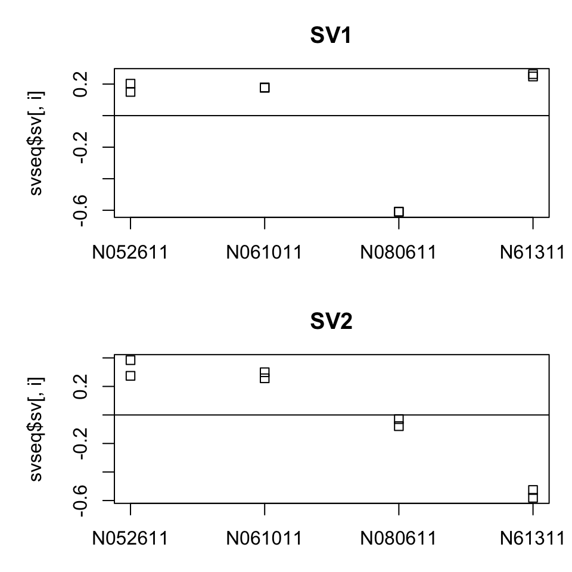

```r
par(mfrow = c(2, 1), mar = c(3,5,3,1))
for (i in 1:2) {
  stripchart(svseq$sv[, i] ~ dds$cell, vertical = TRUE, main = paste0("SV", i))
  abline(h = 0)
 }
```

**Surrogate variables 1 and 2 plotted over cell line.** 这里，我们知道隐藏的变异资料（细胞系），因此我们能看见SVA程序是怎么鉴定出经细胞系校正的 变异资料的。

最终，为了使用SVA从我们的代理变量移除任何对计数的影响，我们简单地将这两个代理变量作为 *DESeqDataSet* 中的列，并把它们添加到设计中去：

```r
ddssva <- dds
ddssva$SV1 <- svseq$sv[,1]
ddssva$SV2 <- svseq$sv[,2]
design(ddssva) <- ~ SV1 + SV2 + dex
```

之后我们可以在新设计下运行 *DESeq* 来产生代理变量控制的结果。

## 8.2 用DESeq2的RUV

我们也可以使用 *RUVSeq* 包中的 *RUV* 方法来检测隐含的批次效应。

```r
library("RUVSeq")
```

We can use the `RUVg` function to estimate *factors of unwanted variation*, analogous to *SVA*’s *surrogate variables*. 与上面的 *SVA* 程序不同的一点是，我们首先要运行 *DESeq* 和 *results* 来获得 批次未知的分析的P值，例如，仅仅 `~ dex`。假设我们有这个结果表格 `res`，之后 通过考虑那些没有一个小P值的基因，我们可以拉出一系列 *empirical control genes* 。

```r
set <- newSeqExpressionSet(counts(dds))
idx  <- rowSums(counts(set) > 5) >= 2
set  <- set[idx, ]
set <- betweenLaneNormalization(set, which="upper")
not.sig <- rownames(res)[which(res$pvalue > .1)]
empirical <- rownames(set)[ rownames(set) %in% not.sig ]
set <- RUVg(set, empirical, k=2)
pData(set)
```

```
##                    W_1         W_2
## SRR1039508 -0.17841946  0.49379636
## SRR1039509 -0.20749027  0.61226276
## SRR1039512 -0.05113443 -0.07266363
## SRR1039513 -0.14974859 -0.07839422
## SRR1039516  0.58209686 -0.05446432
## SRR1039517  0.61285776 -0.04648514
## SRR1039520 -0.28519844 -0.42231712
## SRR1039521 -0.32296344 -0.43173467
```

We can plot the factors estimated by *RUV*:

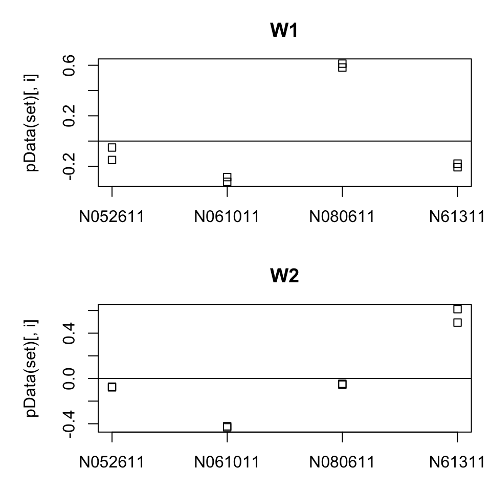

```r
par(mfrow = c(2, 1), mar = c(3,5,3,1))
for (i in 1:2) {
  stripchart(pData(set)[, i] ~ dds$cell, vertical = TRUE, main = paste0("W", i))
  abline(h = 0)
 }
```

**Factors of unwanted variation plotted over cell line.**

As before, if we wanted to control for these factors, we simply add them to the *DESeqDataSet* and to the design:

```r
ddsruv <- dds
ddsruv$W1 <- set$W_1
ddsruv$W2 <- set$W_2
design(ddsruv) <- ~ W1 + W2 + dex
```

之后我们可以在新的设计下运行 *DESeq* 以重新评估参数和结果。

# 9 时间进程实验

*DESeq2* 可用于分析time course实验，例如找到那些与baseline样本比较，随着时间的推移 在特定条件下反应的基因。这里，我们演示了一个 *fission* 数据包的 基础time course分析，其中包含裂殖酵母RNA-seq time course的基因计数(Leong et al. 2014)。 这些酵母暴露于氧化应激，并且其中的一般含有 *atf21* 基因的缺失。 We use a design formula that models the strain difference at time 0, the difference over time, and any strain-specific differences over time (the interaction term `strain:minute`).

```r
library("fission")
data("fission")
ddsTC <- DESeqDataSet(fission, ~ strain + minute + strain:minute)
```

下面的代码块执行似然比检验，我们移除了随时间的指定压力差异。该检验中 *p* 值小的基因是那些 在time 0之后的一个或更多的时间点变现出了strain-specific效应的基因。注意，在两个strains 中以同一种方式随时间上下移动的基因不会被给予小的 *p* 值。

```r
ddsTC <- DESeq(ddsTC, test="LRT", reduced = ~ strain + minute)
resTC <- results(ddsTC)
resTC$symbol <- mcols(ddsTC)$symbol
head(resTC[order(resTC$padj),], 4)
```

```
## log2 fold change (MLE): strainmut.minute180
## LRT p-value: '~ strain + minute + strain:minute' vs '~ strain + minute'
## DataFrame with 4 rows and 7 columns
##                      baseMean      log2FoldChange             lfcSE
##                     <numeric>           <numeric>         <numeric>
## SPBC2F12.09c 174.671161802578   -2.65671953167503 0.752261272511006
## SPAC1002.18  444.504950375698 -0.0509321395109306 0.204299484857632
## SPAC1002.19  336.373206596558  -0.392748982380901  0.57349400917224
## SPAC1002.17c 261.773132733438   -1.13876476912796 0.606128756826876
##                          stat               pvalue                 padj
##                     <numeric>            <numeric>            <numeric>
## SPBC2F12.09c 97.2833864058624 1.97415107530316e-19 1.33452612690494e-15
## SPAC1002.18  56.9535986216334 5.16955159513345e-11 1.74730843915511e-07
## SPAC1002.19  43.5339085771998 2.87980357331426e-08 6.48915738520148e-05
## SPAC1002.17c 39.3158355353091 2.05137078365155e-07 0.000346681662437111
##                   symbol
##              <character>
## SPBC2F12.09c       atf21
## SPAC1002.18         urg3
## SPAC1002.19         urg1
## SPAC1002.17c        urg2
```

这个只是能够应用到time series数据的其中一个检验。另一个可选项是将计数建模为一个时间的光滑函数， 并且在光滑函数中包含一个条件的交互条款。可以使用R中的样条基函数来建立这个模型，更加现代的方法 使用Gaussian processes (Tonner et al. 2017)。

We can plot the counts for the groups over time using *ggplot2*, for the gene with the smallest adjusted *p* value, testing for condition-dependent time profile and accounting for differences at time 0 (figure below). Keep in mind that the interaction terms are the *difference* between the two groups at a given time after accounting for the difference at time 0.

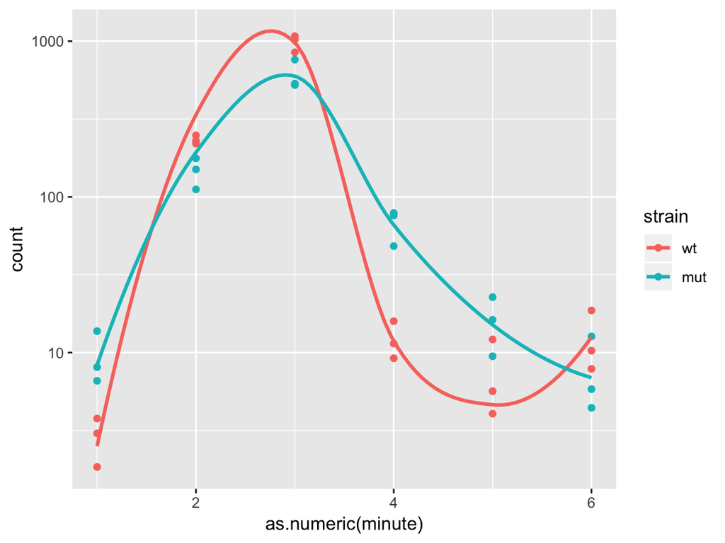

```r
fiss <- plotCounts(ddsTC, which.min(resTC$padj),
                   intgroup = c("minute","strain"), returnData = TRUE)
ggplot(fiss,
  aes(x = as.numeric(minute), y = count, color = strain, group = strain)) +
  geom_point() + geom_smooth(se = FALSE, method = "loess") + scale_y_log10()
```

**Normalized counts for a gene with condition-specific changes over time.**

可以使用 *results* 的 `test` 参数来调查单个时间点上的log2倍数变化的Wald检验：

```r
resultsNames(ddsTC)
```

```
##  [1] "Intercept"           "strain_mut_vs_wt"    "minute_15_vs_0"
##  [4] "minute_30_vs_0"      "minute_60_vs_0"      "minute_120_vs_0"
##  [7] "minute_180_vs_0"     "strainmut.minute15"  "strainmut.minute30"
## [10] "strainmut.minute60"  "strainmut.minute120" "strainmut.minute180"
```

```r
res30 <- results(ddsTC, name="strainmut.minute30", test="Wald")
res30[which.min(resTC$padj),]
```

```
## log2 fold change (MLE): strainmut.minute30
## Wald test p-value: strainmut.minute30
## DataFrame with 1 row and 6 columns
##                      baseMean    log2FoldChange            lfcSE
##                     <numeric>         <numeric>        <numeric>
## SPBC2F12.09c 174.671161802578 -2.60046902875431 0.63434291634409
##                           stat               pvalue              padj
##                      <numeric>            <numeric>         <numeric>
## SPBC2F12.09c -4.09946885470338 4.14099389609056e-05 0.279931187375722
```

我们还可以通过基因的profiles来聚类基因。我们使用 *coef* 函数来提取出一个缩减的log2倍数变化 的矩阵：

```r
betas <- coef(ddsTC)
colnames(betas)
```

```
##  [1] "Intercept"           "strain_mut_vs_wt"    "minute_15_vs_0"
##  [4] "minute_30_vs_0"      "minute_60_vs_0"      "minute_120_vs_0"
##  [7] "minute_180_vs_0"     "strainmut.minute15"  "strainmut.minute30"
## [10] "strainmut.minute60"  "strainmut.minute120" "strainmut.minute180"
```

现在我们可以在热图中画出log2倍数变化（下图）。

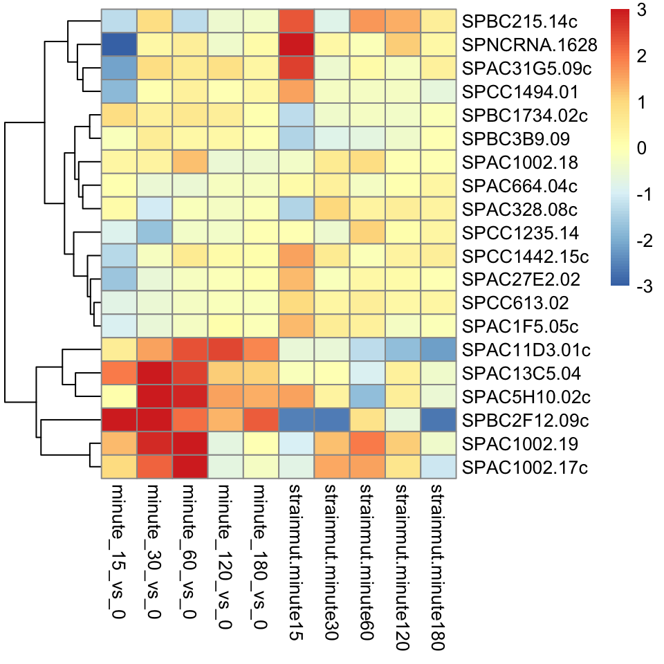

```r
topGenes <- head(order(resTC$padj),20)
mat <- betas[topGenes, -c(1,2)]
thr <- 3
mat[mat < -thr] <- -thr
mat[mat > thr] <- thr
pheatmap(mat, breaks=seq(from=-thr, to=thr, length=101),
         cluster_col=FALSE)
```

**Heatmap of log2 fold changes for genes with smallest adjusted *p* value.**

底部的那组基因表现出15-60分钟内的对基准样本的强烈的诱导表达（左下角的红色框），但是对mutant strain有轻微的差异（展示在右下角的框里）。

# 10 会话信息

作为此文档的最后一部分，我们调用 *sessionInfo* 函数，用来报告在此次会话中使用的R版本 和所有的包的版本。这是一个好习惯，因为当你的包更新了版本，其中的函数可能发生了变化，导致 R脚本停止工作或者给出了不同的结果，这个习惯就会对你有所帮助。将会话信息放在脚本的底部， 你的报告会具有更好的可复用性。

会话信息应该总是连同在分析中使用的代码一起，包含在发给 [Bioconductor support site](https://support.bioconductor.org)的邮件中。

[session information not shown]

# 参考文献

Anders, Simon, and Wolfgang Huber. 2010. “Differential expression analysis for sequence count data.” *Genome Biology* 11 (10): R106+. doi:10.1186/gb-2010-11-10-r106.

Anders, Simon, Paul T. Pyl, and Wolfgang Huber. 2015. “HTSeq – a Python framework to work with high-throughput sequencing data.” *Bioinformatics* 31 (2): 166–69. doi:10.1093/bioinformatics/btu638.

Benjamini, Yoav, and Yosef Hochberg. 1995. “Controlling the False Discovery Rate: A Practical and Powerful Approach to Multiple Testing.” *Journal of the Royal Statistical Society. Series B (Methodological)* 57 (1): 289–300. http://www.jstor.org/stable/2346101.

Bourgon, R., R. Gentleman, and W. Huber. 2010. “Independent filtering increases detection power for high-throughput experiments.” *Proceedings of the National Academy of Sciences* 107 (21): 9546–51. doi:10.1073/pnas.0914005107.

Bray, Nicolas, Harold Pimentel, Pall Melsted, and Lior Pachter. 2016. “Near-Optimal Probabilistic Rna-Seq Quantification.” *Nature Biotechnology* 34: 525–27. http://dx.doi.org/10.1038/nbt.3519.

Dobin, Alexander, Carrie A. Davis, Felix Schlesinger, Jorg Drenkow, Chris Zaleski, Sonali Jha, Philippe Batut, Mark Chaisson, and Thomas R. Gingeras. 2013. “STAR: ultrafast universal RNA-seq aligner.” *Bioinformatics* 29 (1): 15–21. doi:10.1093/bioinformatics/bts635.

Flicek, Paul, M. Ridwan Amode, Daniel Barrell, Kathryn Beal, Konstantinos Billis, Simon Brent, Denise Carvalho-Silva, et al. 2014. “Ensembl 2014.” *Nucleic Acids Research* 42 (D1): D749–D755. doi:10.1093/nar/gkt1196.

Hardcastle, Thomas, and Krystyna Kelly. 2010. “baySeq: Empirical Bayesian methods for identifying differential expression in sequence count data.” *BMC Bioinformatics* 11 (1): 422+. doi:10.1186/1471-2105-11-422.

Himes, Blanca E., Xiaofeng Jiang, Peter Wagner, Ruoxi Hu, Qiyu Wang, Barbara Klanderman, Reid M. Whitaker, et al. 2014. “RNA-Seq transcriptome profiling identifies CRISPLD2 as a glucocorticoid responsive gene that modulates cytokine function in airway smooth muscle cells.” *PloS One* 9 (6). doi:10.1371/journal.pone.0099625.

Huber, Wolfgang, Vincent J. Carey, Robert Gentleman, Simon Anders, Marc Carlson, Benilton S. Carvalho, Hector Corrada C. Bravo, et al. 2015. “Orchestrating high-throughput genomic analysis with Bioconductor.” *Nature Methods* 12 (2). Nature Publishing Group: 115–21. doi:10.1038/nmeth.3252.

Huntley, Melanie A., Jessica L. Larson, Christina Chaivorapol, Gabriel Becker, Michael Lawrence, Jason A. Hackney, and Joshua S. Kaminker. 2013. “ReportingTools: an automated result processing and presentation toolkit for high-throughput genomic analyses.” *Bioinformatics* 29 (24). Oxford University Press: 3220–1. doi:10.1093/bioinformatics/btt551.

Kent, W. James, Charles W. Sugnet, Terrence S. Furey, Krishna M. Roskin, Tom H. Pringle, Alan M. Zahler, and David Haussler. 2002. “The human genome browser at UCSC.” *Genome Research* 12 (6). Cold Spring Harbor Laboratory Press: 996–1006. doi:10.1101/gr.229102.

Law, Charity W., Yunshun Chen, Wei Shi, and Gordon K. Smyth. 2014. “Voom: precision weights unlock linear model analysis tools for RNA-seq read counts.” *Genome Biology* 15 (2). BioMed Central Ltd: R29+. doi:10.1186/gb-2014-15-2-r29.

Lawrence, Michael, Wolfgang Huber, Hervé Pagès, Patrick Aboyoun, Marc Carlson, Robert Gentleman, Martin T. Morgan, and Vincent J. Carey. 2013. “Software for Computing and Annotating Genomic Ranges.” Edited by Andreas Prlic. *PLoS Computational Biology* 9 (8). Public Library of Science: e1003118+. doi:10.1371/journal.pcbi.1003118.

Leng, N., J. A. Dawson, J. A. Thomson, V. Ruotti, A. I. Rissman, B. M. G. Smits, J. D. Haag, M. N. Gould, R. M. Stewart, and C. Kendziorski. 2013. “EBSeq: an empirical Bayes hierarchical model for inference in RNA-seq experiments.” *Bioinformatics* 29 (8). Oxford University Press: 1035–43. doi:10.1093/bioinformatics/btt087.

Leong, Hui S., Keren Dawson, Chris Wirth, Yaoyong Li, Yvonne Connolly, Duncan L. Smith, Caroline R. Wilkinson, and Crispin J. Miller. 2014. “A global non-coding RNA system modulates fission yeast protein levels in response to stress.” *Nature Communications* 5. doi:10.1038/ncomms4947.

Li, Bo, and Colin N. Dewey. 2011. “RSEM: accurate transcript quantification from RNA-Seq data with or without a reference genome.” *BMC Bioinformatics* 12: 323+. doi:10.1186/1471-2105-12-3231.

Li, Heng, Bob Handsaker, Alec Wysoker, Tim Fennell, Jue Ruan, Nils Homer, Gabor Marth, Goncalo Abecasis, Richard Durbin, and 1000 Genome Project Data Processing Subgroup. 2009. “The Sequence Alignment/Map format and SAMtools.” *Bioinformatics (Oxford, England)* 25 (16). Oxford University Press: 2078–9. doi:10.1093/bioinformatics/btp352.

Liao, Y., G. K. Smyth, and W. Shi. 2014. “featureCounts: an efficient general purpose program for assigning sequence reads to genomic features.” *Bioinformatics* 30 (7). Oxford University Press: 923–30. doi:10.1093/bioinformatics/btt656.

Love, Michael I., John B. Hogenesch, and Rafael A. Irizarry. 2016. “Modeling of Rna-Seq Fragment Sequence Bias Reduces Systematic Errors in Transcript Abundance Estimation.” *Nature Biotechnology* 34 (12): 1287–91. http://dx.doi.org/10.1038/nbt.3682.

Love, Michael I., Wolfgang Huber, and Simon Anders. 2014. “Moderated estimation of fold change and dispersion for RNA-seq data with DESeq2.” *Genome Biology* 15 (12). BioMed Central Ltd: 550+. doi:10.1186/s13059-014-0550-8.

Patro, Rob, Geet Duggal, Michael I. Love, Rafael A. Irizarry, and Carl Kingsford. 2017. “Salmon Provides Fast and Bias-Aware Quantification of Transcript Expression.” *Nature Methods*. http://dx.doi.org/10.1038/nmeth.4197.

Patro, Rob, Stephen M. Mount, and Carl Kingsford. 2014. “Sailfish enables alignment-free isoform quantification from RNA-seq reads using lightweight algorithms.” *Nature Biotechnology* 32: 462–64. doi:10.1038/nbt.2862.

Robert, Christelle, and Mick Watson. 2015. “Errors in RNA-Seq quantification affect genes of relevance to human disease.” *Genome Biology*. doi:10.1186/s13059-015-0734-x.

Robinson, M. D., D. J. McCarthy, and G. K. Smyth. 2009. “edgeR: a Bioconductor package for differential expression analysis of digital gene expression data.” *Bioinformatics* 26 (1). Oxford University Press: 139–40. doi:10.1093/bioinformatics/btp616.

Schurch, Nicholas J., Pieta Schofield, Marek Gierlinski, Christian Cole, Alexander Sherstnev, Vijender Singh, Nicola Wrobel, et al. 2016. “How Many Biological Replicates Are Needed in an Rna-Seq Experiment and Which Differential Expression Tool Should You Use?” 22 (6): 839–51. doi:10.1261/rna.053959.115.

Soneson, Charlotte, Michael I. Love, and Mark Robinson. 2015. “Differential analyses for RNA-seq: transcript-level estimates improve gene-level inferences.” *F1000Research* 4 (1521). doi:10.12688/f1000research.7563.1.

Tonner, Peter D, Cynthia L Darnell, Barbara E Engelhardt, and Amy K Schmid. 2017. “Detecting differential growth of microbial populations with Gaussian process regression.” *Genome Research* 27: 320–33. doi:10.1101/gr.210286.116.

Trapnell, Cole, David G Hendrickson, Martin Sauvageau, Loyal Goff, John L Rinn, and Lior Pachter. 2013. “Differential analysis of gene regulation at transcript resolution with RNA-seq.” *Nature Biotechnology*. doi:10.1038/nbt.2450.

Wickham, Hadley. 2009. *ggplot2*. New York, NY: Springer New York. doi:10.1007/978-0-387-98141-3.

Witten, Daniela M. 2011. “Classification and clustering of sequencing data using a Poisson model.” *The Annals of Applied Statistics* 5 (4): 2493–2518. doi:10.1214/11-AOAS493.

Wu, Hao, Chi Wang, and Zhijin Wu. 2013. “A new shrinkage estimator for dispersion improves differential expression detection in RNA-seq data.” *Biostatistics* 14 (2). Oxford University Press: 232–43. doi:10.1093/biostatistics/kxs033.

Zhu, Anqi, Joseph G. Ibrahim, and Michael I. Love. 2018. “Heavy-Tailed Prior Distributions for Sequence Count Data: Removing the Noise and Preserving Large Differences.” *bioRxiv*. https://doi.org/10.1101/303255.